# PCIT-CoS-Waitlist RCT Paper 1: Parent & Child Behaviour Outcomes

#### Model & Results

A linear mixed model with random effect for individual and fixed effects of group, time and the interaction was run. Estimated marginal means were obtained, and contrasts specified to test Hypothesis 1 and Hypothesis 2.

```
## fixed-effect model matrix is rank deficient so dropping 1 column / coefficient
```

```
## refitting model(s) with ML (instead of REML)
```

|  | Effect | npar | AIC | BIC | logLik | deviance | Chisq | Df | Pr(>Chisq) |
| --- | --- | --- | --- | --- | --- | --- | --- | --- | --- |
| result0 | Intercept | 3 | 836.6376 | 845.6894 | -415.3188 | 830.6376 | NA | NA | NA |
| result0_5 | Lie Score (pre) | 4 | 821.7556 | 833.8248 | -406.8778 | 813.7556 | 16.881950 | 1 | 0.0000398 |
| result1 | Lie + Group | 6 | 822.4896 | 840.5933 | -405.2448 | 810.4896 | 3.266004 | 2 | 0.1953423 |
| result2 | Lie + Group + Time | 8 | 820.0259 | 844.1642 | -402.0130 | 804.0259 | 6.463684 | 2 | 0.0394847 |
| result3 | Lie + Group*Time | 11 | 821.9350 | 855.1251 | -399.9675 | 799.9350 | 4.090911 | 3 | 0.2518132 |

```r
summary(result3)
```

```
## Linear mixed model fit by REML. t-tests use Satterthwaite's method [
## lmerModLmerTest]
## Formula: outcome ~ prebcap_lie + group * time + (1 | id)
##    Data: dat
##
## REML criterion at convergence: 789.7
##
## Scaled residuals:
##      Min       1Q   Median       3Q      Max
## -2.59957 -0.34477 -0.07668  0.32554  3.04942
##
## Random effects:
##  Groups   Name        Variance Std.Dev.
##  id       (Intercept) 14.536   3.813
##  Residual              4.495   2.120
## Number of obs: 151, groups:  id, 82
##
## Fixed effects:
##               Estimate Std. Error        df t value Pr(>|t|)
## (Intercept)   2.031243   1.200126 88.537256   1.693   0.0941 .
## prebcap_lie   1.202306   0.286940 81.516556   4.190 7.02e-05 ***
## group2        1.909049   1.163534 94.662852   1.641   0.1042
## group3        0.873530   1.191381 95.934849   0.733   0.4652
## time2        -0.699022   0.623229 69.599173  -1.122   0.2659
## time3        -0.336427   0.718590 70.690590  -0.468   0.6411
## group2:time2  0.009725   1.104784 74.105557   0.009   0.9930
## group3:time2 -0.936895   0.945522 70.727754  -0.991   0.3251
## group2:time3 -2.387221   1.521545 73.474252  -1.569   0.1210
## ---
## Signif. codes:  0 '***' 0.001 '**' 0.01 '*' 0.05 '.' 0.1 ' ' 1
##
## Correlation of Fixed Effects:
##             (Intr) prbcp_ group2 group3 time2  time3  grp2:2 grp3:2
## prebcap_lie -0.745
## group2      -0.406 -0.072
## group3      -0.415 -0.045  0.466
## time2       -0.218  0.008  0.219  0.214
## time3       -0.185 -0.001  0.192  0.188  0.422
## group2:tim2  0.118  0.002 -0.253 -0.121 -0.564 -0.238
## group3:tim2  0.152 -0.017 -0.143 -0.315 -0.659 -0.278  0.372
## group2:tim3  0.097 -0.012 -0.184 -0.088 -0.199 -0.472  0.340  0.132
## fit warnings:
## fixed-effect model matrix is rank deficient so dropping 1 column / coefficient
```

#### Estimated Means & Change

Estimated means for each Treatment and Time are presented. In addition, within-group change between time points is presented with 95% CIs.

```
## group = 1:
##  time emmean    SE    df lower.CL upper.CL
##  1      5.98 0.803  94.0     4.39     7.57
##  2      5.28 0.846 108.3     3.60     6.96
##  3      5.64 0.917 128.1     3.83     7.46
##
## group = 2:
##  time emmean    SE    df lower.CL upper.CL
##  1      7.89 0.840  92.4     6.22     9.56
##  2      7.20 1.101 141.2     5.02     9.38
##  3      5.17 1.478 122.0     2.24     8.09
##
## group = 3:
##  time emmean    SE    df lower.CL upper.CL
##  1      6.85 0.880  94.8     5.11     8.60
##  2      5.22 0.942 112.6     3.35     7.08
##  3    nonEst    NA    NA       NA       NA
##
## Degrees-of-freedom method: kenward-roger
## Confidence level used: 0.95
```

```
## group = 1:
##  contrast estimate    SE   df lower.CL upper.CL
##  1 - 2       0.699 0.624 67.9  -0.7964     2.19
##  1 - 3       0.336 0.720 69.0  -1.3880     2.06
##  2 - 3      -0.363 0.726 66.5  -2.1039     1.38
##
## group = 2:
##  contrast estimate    SE   df lower.CL upper.CL
##  1 - 2       0.689 0.916 74.6  -1.5005     2.88
##  1 - 3       2.724 1.346 72.5  -0.4959     5.94
##  2 - 3       2.034 1.368 67.6  -1.2438     5.31
##
## group = 3:
##  contrast estimate    SE   df lower.CL upper.CL
##  1 - 2       1.636 0.712 69.9  -0.0701     3.34
##  1 - 3      nonEst    NA   NA       NA       NA
##  2 - 3      nonEst    NA   NA       NA       NA
##
## Degrees-of-freedom method: kenward-roger
## Confidence level used: 0.95
## Conf-level adjustment: tukey method for comparing a family of 3 estimates
```

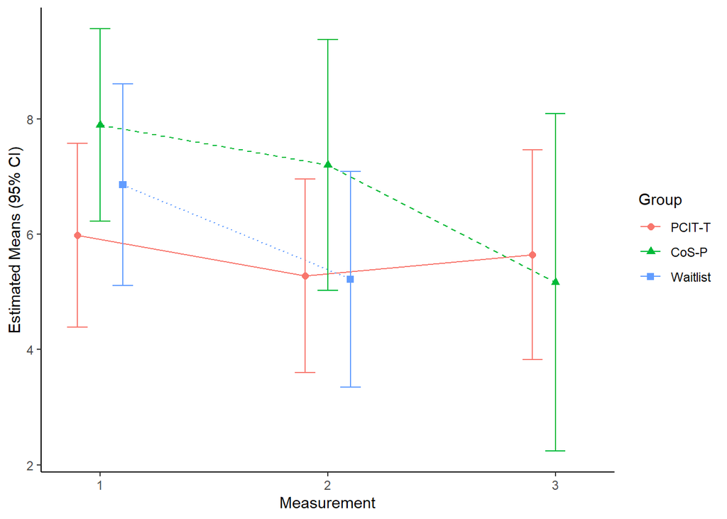

#### Hypothesis 1

We hypothesize that from baseline (‘T1’) to post-treatment/waitlist (‘T2’) there will be a gradient effect, whereby parent-child dyads who receive PCIT-T will show the greatest gains and parent-child dyads who receive no treatment will show the least gains. For the outcome, then, the null hypothesis is:

$H_0: \text {mean change}(\text{PCIT-T}) = \text {mean change}(\text{CoS-P}) = \text {mean change}(\text{Waitlist})$ $H_A: \text {mean change}(\text{PCIT-T}) > \text {mean change}(\text{CoS-P}) > \text {mean change}(\text{Waitlist})$

This is a joint hypothesis test.

First, confirming that the ordering of the means is as hypothesized:

```
## group = 1:
##  contrast estimate    SE   df t.ratio p.value
##  1 - 2       0.699 0.624 67.9   1.120  0.5051
##  1 - 3       0.336 0.720 69.0   0.467  0.8868
##  2 - 3      -0.363 0.726 66.5  -0.499  0.8719
##
## group = 2:
##  contrast estimate    SE   df t.ratio p.value
##  1 - 2       0.689 0.916 74.6   0.753  0.7329
##  1 - 3       2.724 1.346 72.5   2.024  0.1136
##  2 - 3       2.034 1.368 67.6   1.487  0.3034
##
## group = 3:
##  contrast estimate    SE   df t.ratio p.value
##  1 - 2       1.636 0.712 69.9   2.296  0.0629
##  1 - 3      nonEst    NA   NA      NA      NA
##  2 - 3      nonEst    NA   NA      NA      NA
##
## Degrees-of-freedom method: kenward-roger
## P value adjustment: tukey method for comparing a family of 3 estimates
```

Now, to get the p-value associated with the joint hypothesis.

```
##   (Intercept) prebcap_lie group2 group3 time2 time3 group2:time2 group3:time2
## 1           0           0      0      0     0     0            1            0
## 2           0           0      0      0     0     1            0            1
##   group2:time3
## 1            0
## 2            0
```

```
##
##   General Linear Hypotheses
##
## Linear Hypotheses:
##         Estimate
## 1 == 0  0.009725
## 2 == 0 -1.273322
##
## Global Test:
##       F DF1 DF2 Pr(>F)
## 1 0.813   2 140 0.4456
```

p>0.05, so we cannot reject the null hypothesis.

#### Hypothesis 2

There will be a gradient of size of change from T2 to T3 such that the change in the PCIT-T group > the change in the CoS-P group. This isn’t really a gradient; it’s just 1 hypothesis.

First, the changw in PCITT and COSP from time 2 to time 3:

```
## group = 1:
##  contrast estimate    SE   df t.ratio p.value
##  1 - 2       0.699 0.624 67.9   1.120  0.5051
##  1 - 3       0.336 0.720 69.0   0.467  0.8868
##  2 - 3      -0.363 0.726 66.5  -0.499  0.8719
##
## group = 2:
##  contrast estimate    SE   df t.ratio p.value
##  1 - 2       0.689 0.916 74.6   0.753  0.7329
##  1 - 3       2.724 1.346 72.5   2.024  0.1136
##  2 - 3       2.034 1.368 67.6   1.487  0.3034
##
## group = 3:
##  contrast estimate    SE   df t.ratio p.value
##  1 - 2       1.636 0.712 69.9   2.296  0.0629
##  1 - 3      nonEst    NA   NA      NA      NA
##  2 - 3      nonEst    NA   NA      NA      NA
##
## Degrees-of-freedom method: kenward-roger
## P value adjustment: tukey method for comparing a family of 3 estimates
```

```
##
##   Simultaneous Tests for General Linear Hypotheses
##
## Fit: lmer(formula = outcome ~ prebcap_lie + group * time + (1 | id),
##     data = dat)
##
## Linear Hypotheses:
##        Estimate Std. Error z value Pr(>|z|)
## 1 == 0   -2.397      1.547   -1.55    0.121
## (Adjusted p values reported -- single-step method)
```

p>0.05, so we do not have enough evidence to suggest that the change from t2 to t3 in PCITT is greater than the change in COSP.

#### Residuals

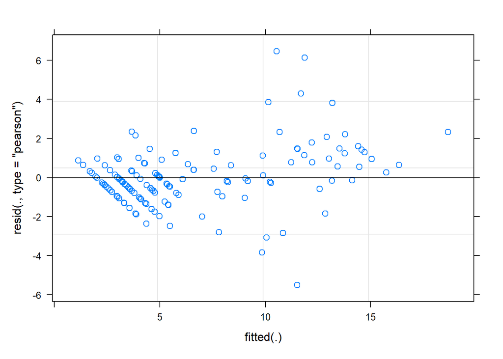

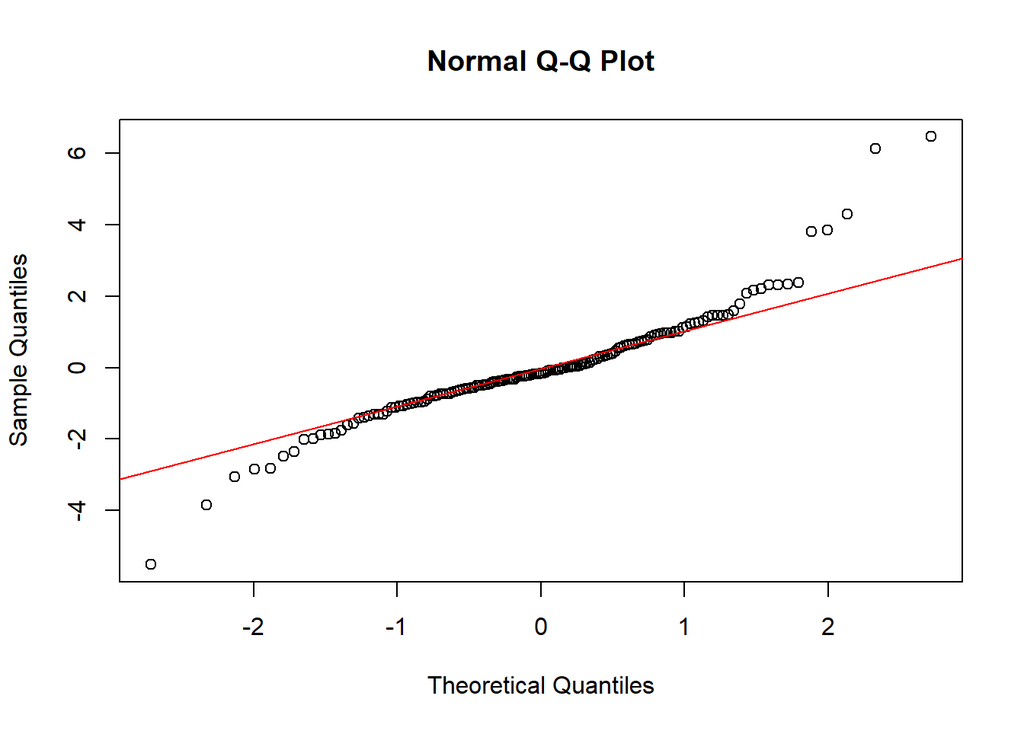

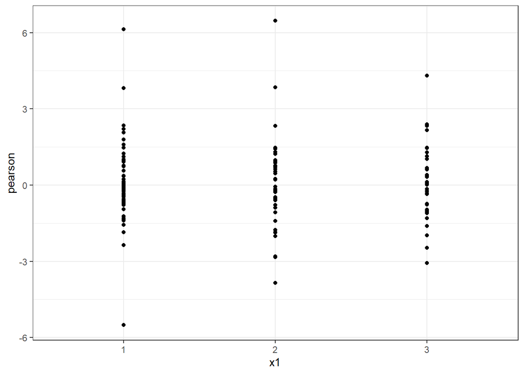

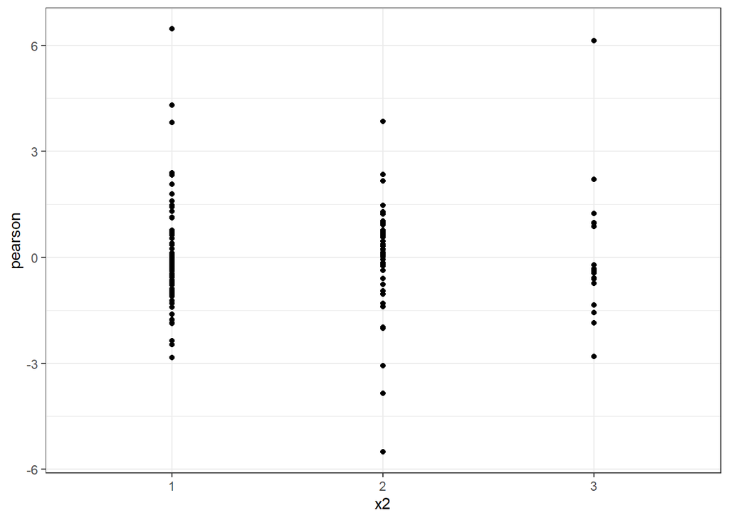

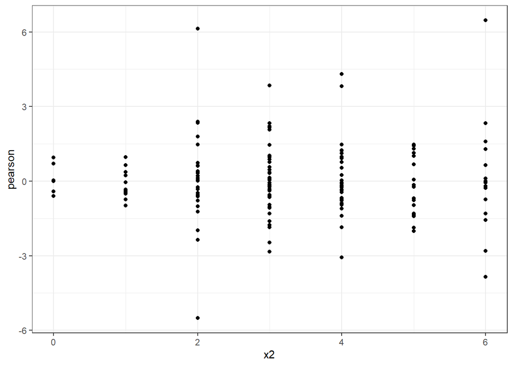

```r
rm(list = ls())
```

### DPICS LP

#### Descriptives

| group | time | n | mean | sd | median | min | max |
| --- | --- | --- | --- | --- | --- | --- | --- |
| 1 | 1 | 30 | 0.2210880 | 0.3206588 | 0.0000000 | 0.0000000 | 1.2145749 |
| 1 | 2 | 22 | 5.5382177 | 2.5986858 | 5.9042553 | 1.0060362 | 11.4503817 |
| 1 | 3 | 18 | 3.3895218 | 3.2501617 | 2.5254669 | 0.3012048 | 14.1479100 |
| 2 | 1 | 29 | 0.3814791 | 0.6888285 | 0.0000000 | 0.0000000 | 2.7848101 |
| 2 | 2 | 12 | 0.6698353 | 0.8628171 | 0.4459375 | 0.0000000 | 2.9702970 |
| 2 | 3 | 5 | 0.3891770 | 0.2192215 | 0.3690037 | 0.1715266 | 0.7352941 |
| 3 | 1 | 30 | 0.4496523 | 0.7171679 | 0.0000000 | 0.0000000 | 2.9629630 |
| 3 | 2 | 26 | 0.5435205 | 0.7550378 | 0.2163444 | 0.0000000 | 2.9197080 |
| 3 | 3 | 1 | 1.2704174 | NA | 1.2704174 | 1.2704174 | 1.2704174 |

#### Model & Results

A generalized linear mixed model (GLMM) with random effect for individual and fixed effects of group, time and the interaction was run on the number of LP responses in the total number of verbalizations. A binomial distribution was specifed with a logit link. Estimated marginal means were obtained, and contrasts specified to test Hypothesis 1 and Hypothesis 2. Assumptions on the residuals were examined using simulated residuals (see below).

```
## fixed-effect model matrix is rank deficient so dropping 1 column / coefficient
```

This is the ANOVA table for the model. p-values are likelihood ratio tests for adding the new term to the model just before. A p-value <0.05 indicates that adding that term results in better model fit.

|  | Effect | npar | AIC | BIC | logLik | deviance | Chisq | Df | Pr(>Chisq) |
| --- | --- | --- | --- | --- | --- | --- | --- | --- | --- |
| result0 | Intercept | 2 | 1269.8559 | 1276.1509 | -632.9279 | 1265.8559 | NA | NA | NA |
| result1 | Group | 4 | 1243.2126 | 1255.8026 | -617.6063 | 1235.2126 | 30.64326 | 2 | 2e-07 |
| result2 | Time | 6 | 875.2011 | 894.0861 | -431.6006 | 863.2011 | 372.01153 | 2 | 0e+00 |
| result3 | Group*Time | 9 | 742.5177 | 770.8451 | -362.2588 | 724.5177 | 138.68344 | 3 | 0e+00 |

```r
summary(result3)
```

```
## Generalized linear mixed model fit by maximum likelihood (Laplace
##   Approximation) [glmerMod]
##  Family: binomial  ( logit )
## Formula: cbind(lp, verbal - lp) ~ group + time + group * time + (1 | id)
##    Data: p
##
##      AIC      BIC   logLik deviance df.resid
##    742.5    770.8   -362.3    724.5      163
##
## Scaled residuals:
##     Min      1Q  Median      3Q     Max
## -1.9562 -0.7088 -0.4371  0.4957  3.9637
##
## Random effects:
##  Groups Name        Variance Std.Dev.
##  id     (Intercept) 0.9447   0.972
## Number of obs: 172, groups:  id, 89
##
## Fixed effects:
##              Estimate Std. Error z value Pr(>|z|)
## (Intercept)   -6.3906     0.2822 -22.647  < 2e-16 ***
## group2         0.3047     0.3882   0.785    0.432
## group3         0.3972     0.3808   1.043    0.297
## time2          3.2791     0.2302  14.245  < 2e-16 ***
## time3          2.7448     0.2371  11.577  < 2e-16 ***
## group2:time2  -2.8549     0.3482  -8.199 2.43e-16 ***
## group3:time2  -3.0894     0.3132  -9.864  < 2e-16 ***
## group2:time3  -2.2530     0.5402  -4.171 3.04e-05 ***
## ---
## Signif. codes:  0 '***' 0.001 '**' 0.01 '*' 0.05 '.' 0.1 ' ' 1
##
## Correlation of Fixed Effects:
##             (Intr) group2 group3 time2  time3  grp2:2 grp3:2
## group2      -0.709
## group3      -0.725  0.561
## time2       -0.702  0.511  0.521
## time3       -0.682  0.497  0.506  0.924
## group2:tim2  0.466 -0.500 -0.341 -0.661 -0.611
## group3:tim2  0.517 -0.373 -0.570 -0.735 -0.679  0.486
## group2:tim3  0.294 -0.372 -0.232 -0.406 -0.439  0.427  0.297
## fit warnings:
## fixed-effect model matrix is rank deficient so dropping 1 column / coefficient
```

#### Estimated Means & Change

Estimated means for each Treatment and Time are presented. In addition, within-group change between time points is presented with 95% CIs.

```r
# type="response" means that the emms are transformed and presented on the orginal scale
# This website has a nice demonstration of emmeans with GLMM https://cran.r-project.org/web/packages/emmeans/vignettes/transformations.html

result.change  <- emmeans(result3, "time", by = "group", type = "response")
# Differences give ODDS RATIOS
result.change.d <-pairs(result.change)
summary(result.change)
```

```
## group = 1:
##  time    prob       SE  df asymp.LCL asymp.UCL
##  1    0.00167 0.000472 Inf  0.000964   0.00291
##  2    0.04263 0.008312 Inf  0.029011   0.06225
##  3    0.02543 0.005235 Inf  0.016960   0.03798
##
## group = 2:
##  time    prob       SE  df asymp.LCL asymp.UCL
##  1    0.00227 0.000620 Inf  0.001329   0.00387
##  2    0.00346 0.001090 Inf  0.001869   0.00641
##  3    0.00371 0.001825 Inf  0.001410   0.00970
##
## group = 3:
##  time    prob       SE  df asymp.LCL asymp.UCL
##  1    0.00249 0.000652 Inf  0.001489   0.00416
##  2    0.00301 0.000792 Inf  0.001795   0.00504
##  3     nonEst       NA  NA        NA        NA
##
## Confidence level used: 0.95
## Intervals are back-transformed from the logit scale
```

```r
confint(result.change.d)
```

```
## group = 1:
##  contrast odds.ratio      SE  df asymp.LCL asymp.UCL
##  1 / 2        0.0377 0.00867 Inf    0.0220    0.0646
##  1 / 3        0.0643 0.01524 Inf    0.0369    0.1120
##  2 / 3        1.7064 0.15594 Inf    1.3774    2.1139
##
## group = 2:
##  contrast odds.ratio      SE  df asymp.LCL asymp.UCL
##  1 / 2        0.6543 0.17095 Inf    0.3546    1.2070
##  1 / 3        0.6116 0.29680 Inf    0.1961    1.9073
##  2 / 3        0.9348 0.46192 Inf    0.2936    2.9763
##
## group = 3:
##  contrast odds.ratio      SE  df asymp.LCL asymp.UCL
##  1 / 2        0.8272 0.17571 Inf    0.5028    1.3608
##  1 / 3        nonEst      NA  NA        NA        NA
##  2 / 3        nonEst      NA  NA        NA        NA
##
## Confidence level used: 0.95
## Conf-level adjustment: tukey method for comparing a family of 3 estimates
## Intervals are back-transformed from the log odds ratio scale
```

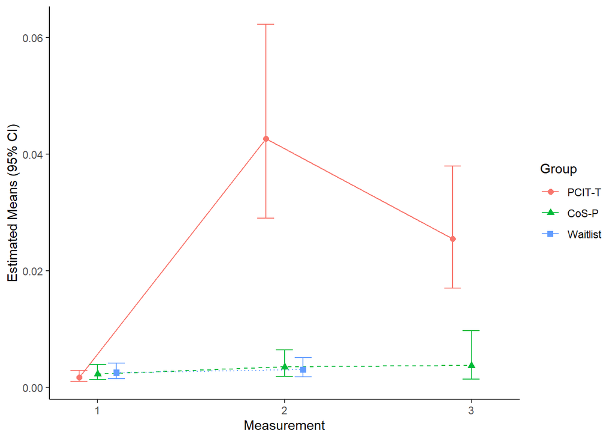

#### Hypothesis 1

We hypothesize that from baseline (‘T1’) to post-treatment/waitlist (‘T2’) there will be a gradient effect, whereby parent-child dyads who receive PCIT-T will show the greatest gains and parent-child dyads who receive no treatment will show the least gains. For the outcome, then, the null hypothesis is:

$H_0: \text {mean change}(\text{PCIT-T}) = \text {mean change}(\text{CoS-P}) = \text {mean change}(\text{Waitlist})$ $H_A: \text {mean change}(\text{PCIT-T}) > \text {mean change}(\text{CoS-P}) > \text {mean change}(\text{Waitlist})$

This is a joint hypothesis test.

First, confirming that the orderig of the means is as hypothesized:

```
## group = 1:
##  contrast odds.ratio      SE  df asymp.LCL asymp.UCL
##  1 / 2        0.0377 0.00867 Inf    0.0220    0.0646
##  1 / 3        0.0643 0.01524 Inf    0.0369    0.1120
##  2 / 3        1.7064 0.15594 Inf    1.3774    2.1139
##
## group = 2:
##  contrast odds.ratio      SE  df asymp.LCL asymp.UCL
##  1 / 2        0.6543 0.17095 Inf    0.3546    1.2070
##  1 / 3        0.6116 0.29680 Inf    0.1961    1.9073
##  2 / 3        0.9348 0.46192 Inf    0.2936    2.9763
##
## group = 3:
##  contrast odds.ratio      SE  df asymp.LCL asymp.UCL
##  1 / 2        0.8272 0.17571 Inf    0.5028    1.3608
##  1 / 3        nonEst      NA  NA        NA        NA
##  2 / 3        nonEst      NA  NA        NA        NA
##
## Confidence level used: 0.95
## Conf-level adjustment: tukey method for comparing a family of 3 estimates
## Intervals are back-transformed from the log odds ratio scale
```

so, change from t1 to t2 is represented as an OR. They way these results are presnted, a value <1means that there is an *increase* from T1 to T2. So, for PCIT-T, the OR=0.0377, indicating that the odds of a LP action in the total verbalisations is much smaller by a factor of 0.037. Alternatively, we can take the reciprocal

$\frac{1}{0.037} = 26.5252$

and the CI limits:

$\frac{1}{0.0646} = 15.4799$

$\frac{1}{0.0220} = 45.4546$

Here, the odds of an LP verbalisation are 26 times higher at time 2 than time 1 for PCIT-T. You should temper this HUGE number with the fact that the proportions of LP actions is very small, regardless of the time and group, however (.2% at time 1, and 4.2% at time 2 for PCIT-T.

Now, to get the p-value associated with the joint hypothesis.

```r
## Specify contrast matrices
# Hyp1 is 1 df test
# could use alternative="less" ir alternative="greater" in glht
hyp1   <- matrix(c(0, 0,0, 0,0, -1,0,0 ),1)
# Hyp2 is 1 df test,
hyp2   <- matrix(c(0, 0,0, 0,1, 0,1,0 ),1)


# hypF is combined 2df test. Yes!
h<-rbind(hyp1,hyp2)
hypF <- as.matrix(h)
GlobalF <- glht(result3, linfct = hypF, test = Ftest())
GlobalF$linfct
```

```
##   (Intercept) group2 group3 time2 time3 group2:time2 group3:time2 group2:time3
## 1           0      0      0     0     0           -1            0            0
## 2           0      0      0     0     1            0            1            0
```

```r
summary(GlobalF, test = Ftest())
```

```
##
##   General Linear Hypotheses
##
## Linear Hypotheses:
##        Estimate
## 1 == 0   2.8549
## 2 == 0  -0.3446
##
## Global Test:
##       F DF1 DF2    Pr(>F)
## 1 34.36   2 163 3.533e-13
```

```r
#also see this webpage for more on contrasts https://rcompanion.org/rcompanion/h_01.html
```

p<0.05 so this hypothesis is supported.

#### Hypothesis 2

There will be a gradient of size of change from T2 to T3 such that the change in the PCIT-T group > the change in the CoS-P group. This isn’t really a gradient; it’s just 1 hypothesis.

First, the change in PCITT and COSP from time 2 to time 3:

```
## group = 1:
##  time    prob       SE  df asymp.LCL asymp.UCL
##  1    0.00167 0.000472 Inf  0.000964   0.00291
##  2    0.04263 0.008312 Inf  0.029011   0.06225
##  3    0.02543 0.005235 Inf  0.016960   0.03798
##
## group = 2:
##  time    prob       SE  df asymp.LCL asymp.UCL
##  1    0.00227 0.000620 Inf  0.001329   0.00387
##  2    0.00346 0.001090 Inf  0.001869   0.00641
##  3    0.00371 0.001825 Inf  0.001410   0.00970
##
## group = 3:
##  time    prob       SE  df asymp.LCL asymp.UCL
##  1    0.00249 0.000652 Inf  0.001489   0.00416
##  2    0.00301 0.000792 Inf  0.001795   0.00504
##  3     nonEst       NA  NA        NA        NA
##
## Confidence level used: 0.95
## Intervals are back-transformed from the logit scale
```

```
## group = 1:
##  contrast odds.ratio      SE  df asymp.LCL asymp.UCL
##  1 / 2        0.0377 0.00867 Inf    0.0220    0.0646
##  1 / 3        0.0643 0.01524 Inf    0.0369    0.1120
##  2 / 3        1.7064 0.15594 Inf    1.3774    2.1139
##
## group = 2:
##  contrast odds.ratio      SE  df asymp.LCL asymp.UCL
##  1 / 2        0.6543 0.17095 Inf    0.3546    1.2070
##  1 / 3        0.6116 0.29680 Inf    0.1961    1.9073
##  2 / 3        0.9348 0.46192 Inf    0.2936    2.9763
##
## group = 3:
##  contrast odds.ratio      SE  df asymp.LCL asymp.UCL
##  1 / 2        0.8272 0.17571 Inf    0.5028    1.3608
##  1 / 3        nonEst      NA  NA        NA        NA
##  2 / 3        nonEst      NA  NA        NA        NA
##
## Confidence level used: 0.95
## Conf-level adjustment: tukey method for comparing a family of 3 estimates
## Intervals are back-transformed from the log odds ratio scale
```

```r
## Specify contrast matrices
# Hyp1 is 1 df test
# could use alternative="less" ir alternative="greater" in glht
hyp2   <- matrix(c(0, 0,0, 0,0, -1,0,1 ),1)
hyp2F <- glht(result3, linfct = hyp2)
summary(hyp2F)
```

```
##
##   Simultaneous Tests for General Linear Hypotheses
##
## Fit: glmer(formula = cbind(lp, verbal - lp) ~ group + time + group *
##     time + (1 | id), data = p, family = binomial)
##
## Linear Hypotheses:
##        Estimate Std. Error z value Pr(>|z|)
## 1 == 0   0.6018     0.5025   1.198    0.231
## (Adjusted p values reported -- single-step method)
```

```r
#also see this webpage for more on contrasts https://rcompanion.org/rcompanion/h_01.html
```

p>0.05, so this null hypothesis connote rejected. However, it is important to note that the proportions at time 3 for PCITT (2.5%) and COSP (0.37%) are very different.

#### Residuals

Before interpretation, we should examine model assumptions.

For this model (A generalized linear mixed model with binomial distribution and logit link, with random effect for individual), we have to use a different residual than for a linear mixed model. These are simulated residuals, using the DHARMa package in R (citation below).

Under H0 (perfect model, no violations of assumptions), we would expect a straight line in the QQplot. Also, the boxes in the boxplot should range homogenously from 0.25-0.75. To see whether there are deviations from this expectation, the plot calculates a test for uniformity per box, and a test for homgeneity of variances between boxes.

```r
library(DHARMa)
```

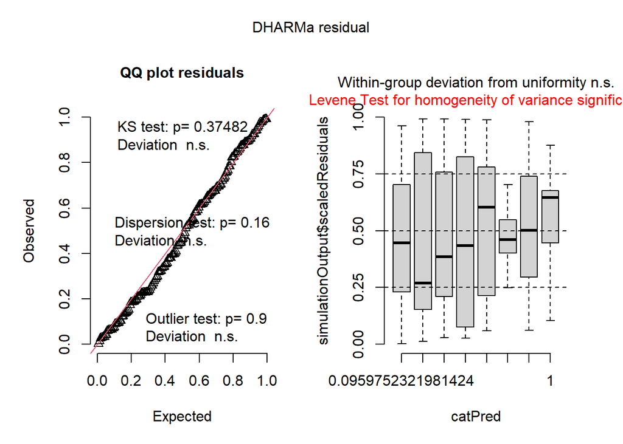

```r
simulationOutput <- simulateResiduals(fittedModel = result3, plot = F)

plot(simulationOutput)
```

```r
citation("DHARMa")
```

```
##
##
##   Florian Hartig (2022). DHARMa: Residual Diagnostics for Hierarchical
##   (Multi-Level / Mixed) Regression Models. R package version 0.4.5.
##   https://CRAN.R-project.org/package=DHARMa
##
## A BibTeX entry for LaTeX users is
##
##   @Manual{,
##     title = {DHARMa: Residual Diagnostics for Hierarchical (Multi-Level / Mixed)
## Regression Models},
##     author = {Florian Hartig},
##     year = {2022},
##     note = {R package version 0.4.5},
##     url = {https://CRAN.R-project.org/package=DHARMa},
##   }
```

```r
rm(list = ls())
```

### DPICS NTA

#### Descriptives

| group | time | n | mean | sd | median | min | max |
| --- | --- | --- | --- | --- | --- | --- | --- |
| 1 | 1 | 30 | 4.1508109 | 3.148392 | 3.5923020 | 0.3745318 | 12.672811 |
| 1 | 2 | 22 | 1.1384618 | 1.389791 | 0.5698052 | 0.0000000 | 5.329949 |
| 1 | 3 | 18 | 0.9306564 | 1.085800 | 0.5343094 | 0.0000000 | 4.385965 |
| 2 | 1 | 29 | 4.1856346 | 3.249028 | 3.4391534 | 0.0000000 | 12.716763 |
| 2 | 2 | 12 | 2.8051659 | 2.860190 | 1.9999126 | 0.0000000 | 9.325397 |
| 2 | 3 | 5 | 3.1532309 | 3.408164 | 1.4760148 | 0.7352941 | 8.809524 |
| 3 | 1 | 30 | 4.6964846 | 4.205556 | 3.1224158 | 0.8333333 | 18.820225 |
| 3 | 2 | 26 | 2.3054638 | 2.197483 | 1.8675059 | 0.0000000 | 9.285714 |
| 3 | 3 | 1 | 0.9074410 | NA | 0.9074410 | 0.9074410 | 0.907441 |

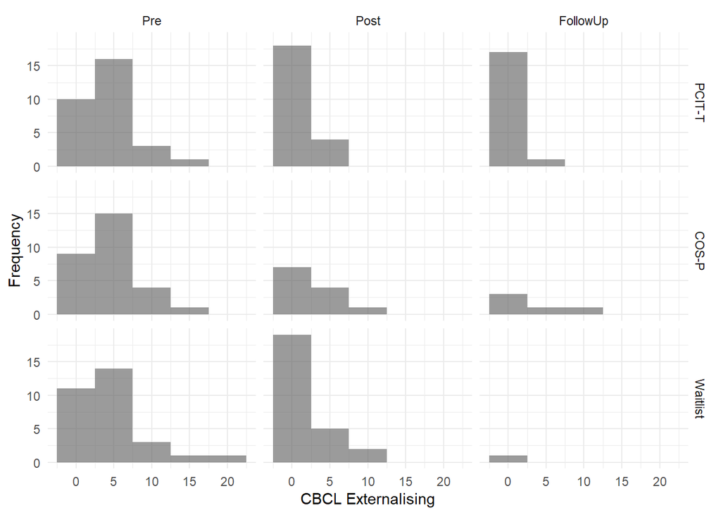

#### Model & Results

```
## fixed-effect model matrix is rank deficient so dropping 1 column / coefficient
```

This is the ANOVA table for the model. p-values are likelihood ratio tests for adding the new term to the model just before. A p-value <0.05 indicates that adding that term results in better model fit.

|  | Effect | npar | AIC | BIC | logLik | deviance | Chisq | Df | Pr(>Chisq) |
| --- | --- | --- | --- | --- | --- | --- | --- | --- | --- |
| result0 | Intercept | 2 | 1600.692 | 1606.987 | -798.3459 | 1596.692 | NA | NA | NA |
| result1 | Group | 4 | 1601.202 | 1613.792 | -796.6012 | 1593.202 | 3.489524 | 2 | 0.1746866 |
| result2 | Time | 6 | 1340.383 | 1359.268 | -664.1915 | 1328.383 | 264.819295 | 2 | 0.0000000 |
| result3 | Group*Time | 9 | 1273.513 | 1301.840 | -627.7563 | 1255.513 | 72.870412 | 3 | 0.0000000 |

```r
summary(result3)
```

```
## Generalized linear mixed model fit by maximum likelihood (Laplace
##   Approximation) [glmerMod]
##  Family: binomial  ( logit )
## Formula: cbind(nta, verbal - nta) ~ group + time + group * time + (1 |      id)
##    Data: p
##
##      AIC      BIC   logLik deviance df.resid
##   1273.5   1301.8   -627.8   1255.5      163
##
## Scaled residuals:
##     Min      1Q  Median      3Q     Max
## -3.6042 -0.9502 -0.0342  0.4303  4.2112
##
## Random effects:
##  Groups Name        Variance Std.Dev.
##  id     (Intercept) 0.6502   0.8063
## Number of obs: 172, groups:  id, 89
##
## Fixed effects:
##              Estimate Std. Error z value Pr(>|z|)
## (Intercept)   -3.3755     0.1588 -21.260  < 2e-16 ***
## group2        -0.0783     0.2263  -0.346    0.729
## group3         0.1178     0.2230   0.528    0.597
## time2         -1.3744     0.1154 -11.909  < 2e-16 ***
## time3         -1.4937     0.1445 -10.337  < 2e-16 ***
## group2:time2   1.0131     0.1598   6.339 2.31e-10 ***
## group3:time2   0.6078     0.1420   4.281 1.86e-05 ***
## group2:time3   1.5159     0.2187   6.932 4.14e-12 ***
## ---
## Signif. codes:  0 '***' 0.001 '**' 0.01 '*' 0.05 '.' 0.1 ' ' 1
##
## Correlation of Fixed Effects:
##             (Intr) group2 group3 time2  time3  grp2:2 grp3:2
## group2      -0.697
## group3      -0.709  0.497
## time2       -0.124  0.087  0.088
## time3       -0.110  0.077  0.078  0.171
## group2:tim2  0.089 -0.126 -0.064 -0.722 -0.123
## group3:tim2  0.101 -0.071 -0.136 -0.813 -0.139  0.587
## group2:tim3  0.071 -0.105 -0.051 -0.113 -0.661  0.235  0.092
## fit warnings:
## fixed-effect model matrix is rank deficient so dropping 1 column / coefficient
```

#### Estimated Means & Change

Estimated means for each Treatment and Time are presented. In addition, within-group change between time points is presented with 95% CIs.

```r
# type="response" means that the emms are transformed and presented on the orginal scale
# This website has a nice demonstration of emmeans with GLMM https://cran.r-project.org/web/packages/emmeans/vignettes/transformations.html

result.change  <- emmeans(result3, "time", by = "group", type = "response")
# Differences give ODDS RATIOS
result.change.d <-pairs(result.change)
summary(result.change)
```

```
## group = 1:
##  time    prob      SE  df asymp.LCL asymp.UCL
##  1    0.03307 0.00508 Inf   0.02444    0.0446
##  2    0.00858 0.00157 Inf   0.00599    0.0123
##  3    0.00762 0.00153 Inf   0.00514    0.0113
##
## group = 2:
##  time    prob      SE  df asymp.LCL asymp.UCL
##  1    0.03066 0.00482 Inf   0.02249    0.0417
##  2    0.02156 0.00389 Inf   0.01512    0.0307
##  3    0.03132 0.00664 Inf   0.02063    0.0473
##
## group = 3:
##  time    prob      SE  df asymp.LCL asymp.UCL
##  1    0.03705 0.00561 Inf   0.02750    0.0498
##  2    0.01756 0.00286 Inf   0.01275    0.0241
##  3     nonEst      NA  NA        NA        NA
##
## Confidence level used: 0.95
## Intervals are back-transformed from the logit scale
```

```r
confint(result.change.d)
```

```
## group = 1:
##  contrast odds.ratio    SE  df asymp.LCL asymp.UCL
##  1 / 2         3.953 0.456 Inf     3.016      5.18
##  1 / 3         4.454 0.644 Inf     3.174      6.25
##  2 / 3         1.127 0.190 Inf     0.758      1.67
##
## group = 2:
##  contrast odds.ratio    SE  df asymp.LCL asymp.UCL
##  1 / 2         1.435 0.159 Inf     1.108      1.86
##  1 / 3         0.978 0.161 Inf     0.666      1.44
##  2 / 3         0.681 0.115 Inf     0.459      1.01
##
## group = 3:
##  contrast odds.ratio    SE  df asymp.LCL asymp.UCL
##  1 / 2         2.153 0.178 Inf     1.773      2.61
##  1 / 3        nonEst    NA  NA        NA        NA
##  2 / 3        nonEst    NA  NA        NA        NA
##
## Confidence level used: 0.95
## Conf-level adjustment: tukey method for comparing a family of 3 estimates
## Intervals are back-transformed from the log odds ratio scale
```

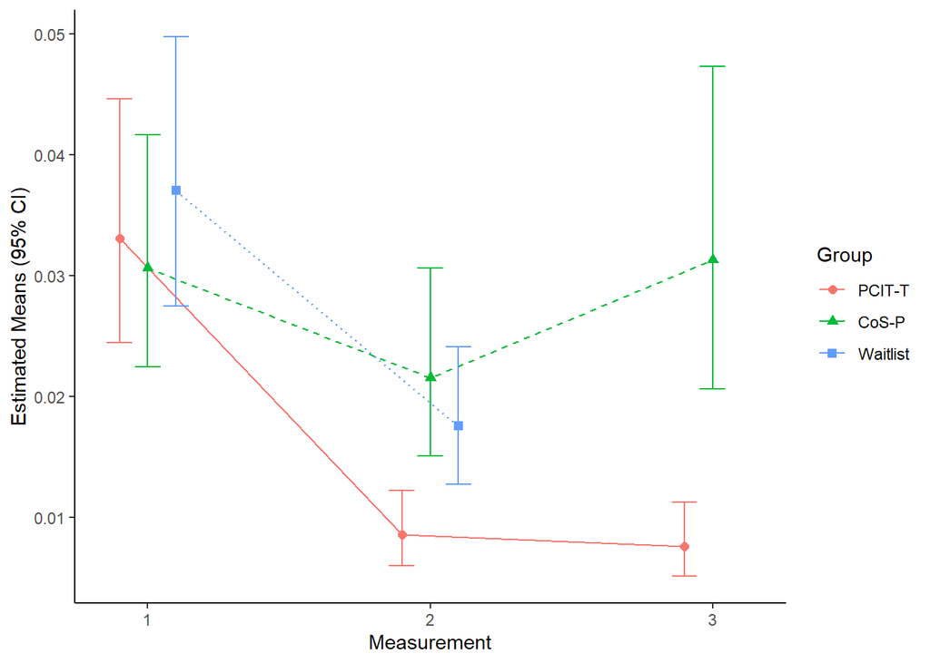

#### Hypothesis 1

We hypothesize that from baseline (‘T1’) to post-treatment/waitlist (‘T2’) there will be a gradient effect, whereby parent-child dyads who receive PCIT-T will show the greatest gains and parent-child dyads who receive no treatment will show the least gains. For the outcome, then, the null hypothesis is:

$H_0: \text {mean change}(\text{PCIT-T}) = \text {mean change}(\text{CoS-P}) = \text {mean change}(\text{Waitlist})$ $H_A: \text {mean change}(\text{PCIT-T}) > \text {mean change}(\text{CoS-P}) > \text {mean change}(\text{Waitlist})$

This is a joint hypothesis test.

First, confirming that the orderig of the means is as hypothesized:

```
## group = 1:
##  contrast odds.ratio    SE  df asymp.LCL asymp.UCL
##  1 / 2         3.953 0.456 Inf     3.016      5.18
##  1 / 3         4.454 0.644 Inf     3.174      6.25
##  2 / 3         1.127 0.190 Inf     0.758      1.67
##
## group = 2:
##  contrast odds.ratio    SE  df asymp.LCL asymp.UCL
##  1 / 2         1.435 0.159 Inf     1.108      1.86
##  1 / 3         0.978 0.161 Inf     0.666      1.44
##  2 / 3         0.681 0.115 Inf     0.459      1.01
##
## group = 3:
##  contrast odds.ratio    SE  df asymp.LCL asymp.UCL
##  1 / 2         2.153 0.178 Inf     1.773      2.61
##  1 / 3        nonEst    NA  NA        NA        NA
##  2 / 3        nonEst    NA  NA        NA        NA
##
## Confidence level used: 0.95
## Conf-level adjustment: tukey method for comparing a family of 3 estimates
## Intervals are back-transformed from the log odds ratio scale
```

so, change from t1 to t2 is represented as an OR. They way these results are presnted, a value >1 means that there is an *decrease* from T1 to T2. So, for PCIT-T, the OR=3.953, indicating that the odds of a NTA action in the total verbalisations is much larger at Time 1 by a factor of 3.953. Alternatively, we can take the reciprocal

$\frac{1}{3.953} = 0.25297$

and the CI limits:

$\frac{1}{5.18} = 0.1930502$

$\frac{1}{3.016} = 0.331565$

Here, the odds of an NTA verbalisation are .25 times the odds at time 2 than time 1 for PCIT-T. Or, there is a 75% decrease in the odds of a NTA verbalisation at Time 2.

Now, to get the p-value associated with the joint hypothesis.

```r
## Specify contrast matrices
# Hyp1 is 1 df test
# could use alternative="less" ir alternative="greater" in glht
hyp1   <- matrix(c(0, 0,0, 0,0, -1,0,0 ),1)
# Hyp2 is 1 df test,
hyp2   <- matrix(c(0, 0,0, 0,1, 0,1,0 ),1)


# hypF is combined 2df test. Yes!
h<-rbind(hyp1,hyp2)
hypF <- as.matrix(h)
GlobalF <- glht(result3, linfct = hypF, test = Ftest())
GlobalF$linfct
```

```
##   (Intercept) group2 group3 time2 time3 group2:time2 group3:time2 group2:time3
## 1           0      0      0     0     0           -1            0            0
## 2           0      0      0     0     1            0            1            0
```

```r
summary(GlobalF, test = Ftest())
```

```
##
##   General Linear Hypotheses
##
## Linear Hypotheses:
##        Estimate
## 1 == 0  -1.0131
## 2 == 0  -0.8859
##
## Global Test:
##       F DF1 DF2    Pr(>F)
## 1 47.37   2 163 6.049e-17
```

```r
#also see this webpage for more on contrasts https://rcompanion.org/rcompanion/h_01.html
```

p<0.05 so this hypothesis is supported. We have evidence to reject the null in favour of the alternative.

#### Hypothesis 2

There will be a gradient of size of change from T2 to T3 such that the change in the PCIT-T group > the change in the CoS-P group. This isn’t really a gradient; it’s just 1 hypothesis.

First, the change in PCITT and COSP from time 2 to time 3:

```
## group = 1:
##  time    prob      SE  df asymp.LCL asymp.UCL
##  1    0.03307 0.00508 Inf   0.02444    0.0446
##  2    0.00858 0.00157 Inf   0.00599    0.0123
##  3    0.00762 0.00153 Inf   0.00514    0.0113
##
## group = 2:
##  time    prob      SE  df asymp.LCL asymp.UCL
##  1    0.03066 0.00482 Inf   0.02249    0.0417
##  2    0.02156 0.00389 Inf   0.01512    0.0307
##  3    0.03132 0.00664 Inf   0.02063    0.0473
##
## group = 3:
##  time    prob      SE  df asymp.LCL asymp.UCL
##  1    0.03705 0.00561 Inf   0.02750    0.0498
##  2    0.01756 0.00286 Inf   0.01275    0.0241
##  3     nonEst      NA  NA        NA        NA
##
## Confidence level used: 0.95
## Intervals are back-transformed from the logit scale
```

```
## group = 1:
##  contrast odds.ratio    SE  df asymp.LCL asymp.UCL
##  1 / 2         3.953 0.456 Inf     3.016      5.18
##  1 / 3         4.454 0.644 Inf     3.174      6.25
##  2 / 3         1.127 0.190 Inf     0.758      1.67
##
## group = 2:
##  contrast odds.ratio    SE  df asymp.LCL asymp.UCL
##  1 / 2         1.435 0.159 Inf     1.108      1.86
##  1 / 3         0.978 0.161 Inf     0.666      1.44
##  2 / 3         0.681 0.115 Inf     0.459      1.01
##
## group = 3:
##  contrast odds.ratio    SE  df asymp.LCL asymp.UCL
##  1 / 2         2.153 0.178 Inf     1.773      2.61
##  1 / 3        nonEst    NA  NA        NA        NA
##  2 / 3        nonEst    NA  NA        NA        NA
##
## Confidence level used: 0.95
## Conf-level adjustment: tukey method for comparing a family of 3 estimates
## Intervals are back-transformed from the log odds ratio scale
```

```r
## Specify contrast matrices
# Hyp1 is 1 df test
# could use alternative="less" ir alternative="greater" in glht
hyp2   <- matrix(c(0, 0,0, 0,0, -1,0,1 ),1)
hyp2F <- glht(result3, linfct = hyp2)
summary(hyp2F)
```

```
##
##   Simultaneous Tests for General Linear Hypotheses
##
## Fit: glmer(formula = cbind(nta, verbal - nta) ~ group + time + group *
##     time + (1 | id), data = p, family = binomial)
##
## Linear Hypotheses:
##        Estimate Std. Error z value Pr(>|z|)
## 1 == 0   0.5029     0.2386   2.108    0.035 *
## ---
## Signif. codes:  0 '***' 0.001 '**' 0.01 '*' 0.05 '.' 0.1 ' ' 1
## (Adjusted p values reported -- single-step method)
```

```r
#also see this webpage for more on contrasts https://rcompanion.org/rcompanion/h_01.html
```

p<0.05,so we rejct the null and have evidence to suggest that the proportions of NTA at time 3 is different for PCITT and COSP.

#### Residuals

Before interpretation, we should examine model assumptions.

For this model (A generalized linear mixed model with binomial distribution and logit link, with random effect for individual), we have to use a different residual than for a linear mixed model. These are simulated residuals, using the DHARMa package in R (citation below).

Under H0 (perfect model, no violations of assumptions), we would expect a straight line in the QQplot. Also, the boxes in the boxplot should range homogenously from 0.25-0.75. To see whether there are deviations from this expectation, the plot calculates a test for uniformity per box, and a test for homgeneity of variances between boxes.

There are no violations of assumptions.

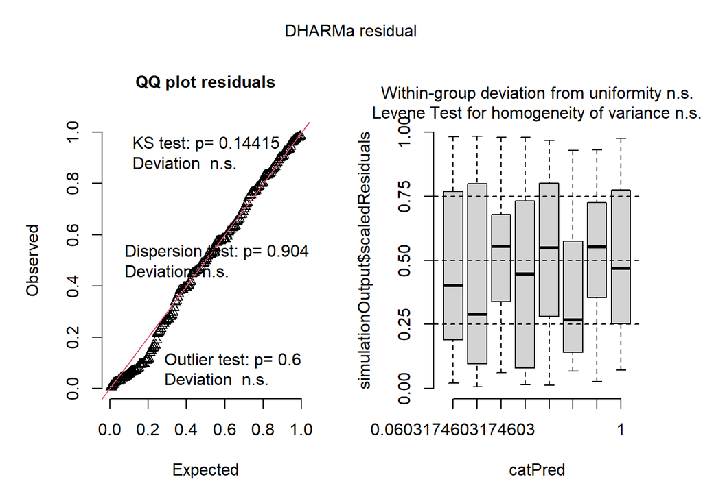

```r
library(DHARMa)

simulationOutput <- simulateResiduals(fittedModel = result3, plot = F)

plot(simulationOutput)
```

```r
citation("DHARMa")
```

```
##
##
##   Florian Hartig (2022). DHARMa: Residual Diagnostics for Hierarchical
##   (Multi-Level / Mixed) Regression Models. R package version 0.4.5.
##   https://CRAN.R-project.org/package=DHARMa
##
## A BibTeX entry for LaTeX users is
##
##   @Manual{,
##     title = {DHARMa: Residual Diagnostics for Hierarchical (Multi-Level / Mixed)
## Regression Models},
##     author = {Florian Hartig},
##     year = {2022},
##     note = {R package version 0.4.5},
##     url = {https://CRAN.R-project.org/package=DHARMa},
##   }
```

```r
rm(list = ls())
```

### DPICS Child Compliance

#### Descriptives

| group | time | n | mean | sd | median | min | max |
| --- | --- | --- | --- | --- | --- | --- | --- |
| 1 | 1 | 29 | 47.04606 | 14.87939 | 43.75000 | 20.000000 | 82.35294 |
| 1 | 2 | 21 | 53.00534 | 12.17461 | 54.54545 | 33.333333 | 75.00000 |
| 1 | 3 | 18 | 54.04649 | 24.98276 | 59.16667 | 10.000000 | 85.00000 |
| 2 | 1 | 29 | 46.62153 | 17.85624 | 42.10526 | 16.000000 | 78.57143 |
| 2 | 2 | 12 | 51.96127 | 25.29084 | 59.83982 | 9.756098 | 79.16667 |
| 2 | 3 | 5 | 65.40371 | 15.58984 | 65.51724 | 47.826087 | 88.88889 |
| 3 | 1 | 28 | 49.11532 | 13.84115 | 49.13793 | 25.000000 | 76.00000 |
| 3 | 2 | 22 | 49.80484 | 17.16227 | 46.17092 | 14.285714 | 79.41176 |
| 3 | 3 | 0 | NaN | NA | NA | Inf | -Inf |

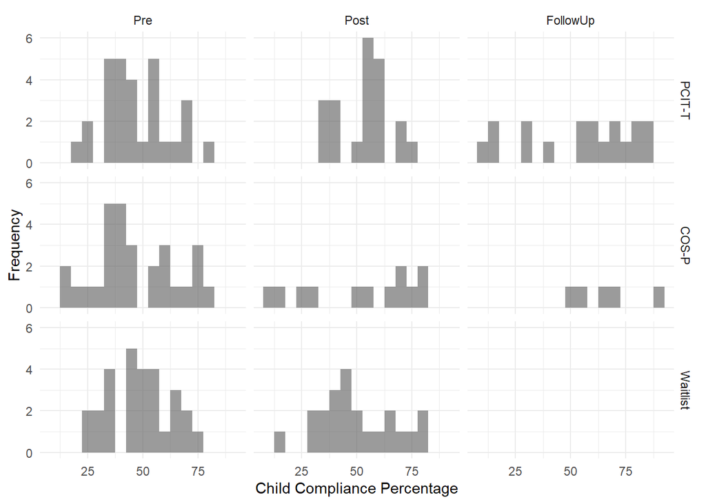

#### Model & Results

TOTAL_eff_commands_TIME_1 is the demoninator, and CHILD_CO_total_TIME_1 is the numerator

```
## fixed-effect model matrix is rank deficient so dropping 1 column / coefficient
```

This is the ANOVA table for the model. p-values are likelihood ratio tests for adding the new term to the model just before. A p-value <0.05 indicates that adding that term results in better model fit.

|  | Effect | npar | AIC | BIC | logLik | deviance | Chisq | Df | Pr(>Chisq) |
| --- | --- | --- | --- | --- | --- | --- | --- | --- | --- |
| result0 | Intercept | 2 | 985.2588 | 991.4585 | -490.6294 | 981.2588 | NA | NA | NA |
| result1 | Group | 4 | 988.9554 | 1001.3549 | -490.4777 | 980.9554 | 0.3033927 | 2 | 0.8592492 |
| result2 | Time | 6 | 987.9122 | 1006.5114 | -487.9561 | 975.9122 | 5.0431777 | 2 | 0.0803319 |
| result3 | Group*Time | 9 | 989.8034 | 1017.7022 | -485.9017 | 971.8034 | 4.1088840 | 3 | 0.2499441 |

```r
summary(result3)
```

```
## Generalized linear mixed model fit by maximum likelihood (Laplace
##   Approximation) [glmerMod]
##  Family: binomial  ( logit )
## Formula: cbind(co, effcommands - co) ~ group + time + group * time + (1 |
##     id)
##    Data: p
##
##      AIC      BIC   logLik deviance df.resid
##    989.8   1017.7   -485.9    971.8      155
##
## Scaled residuals:
##     Min      1Q  Median      3Q     Max
## -3.4159 -0.6971 -0.0701  0.7983  2.5804
##
## Random effects:
##  Groups Name        Variance Std.Dev.
##  id     (Intercept) 0.2591   0.5091
## Number of obs: 164, groups:  id, 88
##
## Fixed effects:
##              Estimate Std. Error z value Pr(>|z|)
## (Intercept)  -0.09684    0.12058  -0.803   0.4219
## group2       -0.03161    0.16998  -0.186   0.8525
## group3        0.07162    0.16807   0.426   0.6700
## time2         0.30520    0.13643   2.237   0.0253 *
## time3         0.20888    0.14371   1.454   0.1461
## group2:time2 -0.11448    0.19921  -0.575   0.5655
## group3:time2 -0.30643    0.17273  -1.774   0.0760 .
## group2:time3  0.16860    0.26451   0.637   0.5239
## ---
## Signif. codes:  0 '***' 0.001 '**' 0.01 '*' 0.05 '.' 0.1 ' ' 1
##
## Correlation of Fixed Effects:
##             (Intr) group2 group3 time2  time3  grp2:2 grp3:2
## group2      -0.709
## group3      -0.718  0.509
## time2       -0.363  0.257  0.261
## time3       -0.362  0.256  0.260  0.389
## group2:tim2  0.249 -0.315 -0.179 -0.684 -0.266
## group3:tim2  0.287 -0.203 -0.358 -0.791 -0.308  0.541
## group2:tim3  0.197 -0.242 -0.142 -0.213 -0.545  0.305  0.170
## fit warnings:
## fixed-effect model matrix is rank deficient so dropping 1 column / coefficient
```

#### Estimated Means & Change

Estimated means for each Treatment and Time are presented. In addition, within-group change between time points is presented with 95% CIs.

```r
# type="response" means that the emms are transformed and presented on the orginal scale
# This website has a nice demonstration of emmeans with GLMM https://cran.r-project.org/web/packages/emmeans/vignettes/transformations.html

result.change  <- emmeans(result3, "time", by = "group", type = "response")
# Differences give ODDS RATIOS
result.change.d <-pairs(result.change)
summary(result.change)
```

```
## group = 1:
##  time   prob     SE  df asymp.LCL asymp.UCL
##  1     0.476 0.0301 Inf     0.417     0.535
##  2     0.552 0.0360 Inf     0.481     0.621
##  3     0.528 0.0375 Inf     0.454     0.600
##
## group = 2:
##  time   prob     SE  df asymp.LCL asymp.UCL
##  1     0.468 0.0298 Inf     0.410     0.527
##  2     0.516 0.0403 Inf     0.437     0.594
##  3     0.562 0.0574 Inf     0.448     0.669
##
## group = 3:
##  time   prob     SE  df asymp.LCL asymp.UCL
##  1     0.494 0.0293 Inf     0.437     0.551
##  2     0.493 0.0317 Inf     0.432     0.555
##  3    nonEst     NA  NA        NA        NA
##
## Confidence level used: 0.95
## Intervals are back-transformed from the logit scale
```

```r
confint(result.change.d)
```

```
## group = 1:
##  contrast odds.ratio    SE  df asymp.LCL asymp.UCL
##  1 / 2         0.737 0.101 Inf     0.535      1.01
##  1 / 3         0.811 0.117 Inf     0.579      1.14
##  2 / 3         1.101 0.171 Inf     0.766      1.58
##
## group = 2:
##  contrast odds.ratio    SE  df asymp.LCL asymp.UCL
##  1 / 2         0.826 0.120 Inf     0.588      1.16
##  1 / 3         0.686 0.152 Inf     0.408      1.15
##  2 / 3         0.830 0.192 Inf     0.482      1.43
##
## group = 3:
##  contrast odds.ratio    SE  df asymp.LCL asymp.UCL
##  1 / 2         1.001 0.106 Inf     0.781      1.28
##  1 / 3        nonEst    NA  NA        NA        NA
##  2 / 3        nonEst    NA  NA        NA        NA
##
## Confidence level used: 0.95
## Conf-level adjustment: tukey method for comparing a family of 3 estimates
## Intervals are back-transformed from the log odds ratio scale
```

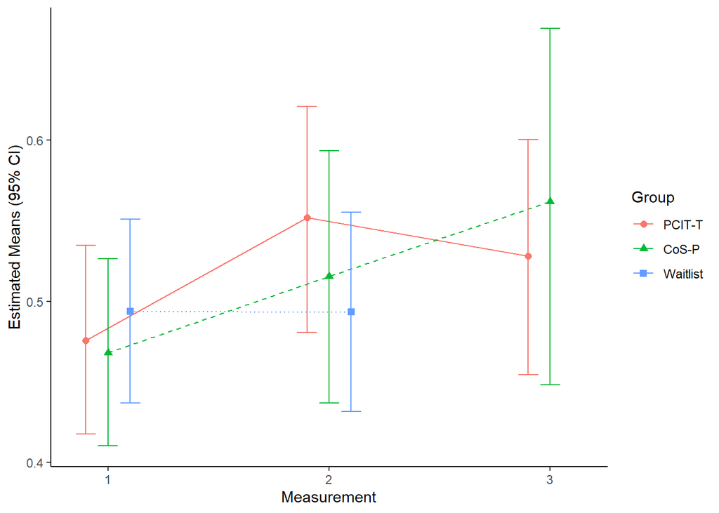

#### Hypothesis 1

We hypothesize that from baseline (‘T1’) to post-treatment/waitlist (‘T2’) there will be a gradient effect, whereby parent-child dyads who receive PCIT-T will show the greatest gains and parent-child dyads who receive no treatment will show the least gains. For the outcome, then, the null hypothesis is:

$H_0: \text {mean change}(\text{PCIT-T}) = \text {mean change}(\text{CoS-P}) = \text {mean change}(\text{Waitlist})$ $H_A: \text {mean change}(\text{PCIT-T}) > \text {mean change}(\text{CoS-P}) > \text {mean change}(\text{Waitlist})$

This is a joint hypothesis test.

First, confirming that the orderig of the means is as hypothesized:

```
## group = 1:
##  contrast odds.ratio    SE  df asymp.LCL asymp.UCL
##  1 / 2         0.737 0.101 Inf     0.535      1.01
##  1 / 3         0.811 0.117 Inf     0.579      1.14
##  2 / 3         1.101 0.171 Inf     0.766      1.58
##
## group = 2:
##  contrast odds.ratio    SE  df asymp.LCL asymp.UCL
##  1 / 2         0.826 0.120 Inf     0.588      1.16
##  1 / 3         0.686 0.152 Inf     0.408      1.15
##  2 / 3         0.830 0.192 Inf     0.482      1.43
##
## group = 3:
##  contrast odds.ratio    SE  df asymp.LCL asymp.UCL
##  1 / 2         1.001 0.106 Inf     0.781      1.28
##  1 / 3        nonEst    NA  NA        NA        NA
##  2 / 3        nonEst    NA  NA        NA        NA
##
## Confidence level used: 0.95
## Conf-level adjustment: tukey method for comparing a family of 3 estimates
## Intervals are back-transformed from the log odds ratio scale
```

so, change from t1 to t2 is represented as an OR. They way these results are presented, a value <1 means that there is an *increase* from T1 to T2. So, for PCIT-T, the OR=0.737, indicating that the odds of a child compliance after effective command islower at Time 1 by a factor of 0.737. Alternatively, we can take the reciprocal

$\frac{1}{0.737} = 1.356852$

and the CI limits:

$\frac{1}{1.01} = 0.9901$

$\frac{1}{0.535} = 1.869159$

Here, the odds of compliance 1.36 times the odds at time 2 than time 1 for PCIT-T. Or, there is a 36% increase in the odds of compliance at Time 2.

Now, to get the p-value associated with the joint hypothesis.

```r
## Specify contrast matrices
# Hyp1 is 1 df test
# could use alternative="less" ir alternative="greater" in glht
hyp1   <- matrix(c(0, 0,0, 0,0, -1,0,0 ),1)
# Hyp2 is 1 df test,
hyp2   <- matrix(c(0, 0,0, 0,1, 0,1,0 ),1)


# hypF is combined 2df test. Yes!
h<-rbind(hyp1,hyp2)
hypF <- as.matrix(h)
GlobalF <- glht(result3, linfct = hypF, test = Ftest())
GlobalF$linfct
```

```
##   (Intercept) group2 group3 time2 time3 group2:time2 group3:time2 group2:time3
## 1           0      0      0     0     0           -1            0            0
## 2           0      0      0     0     1            0            1            0
```

```r
summary(GlobalF, test = Ftest())
```

```
##
##   General Linear Hypotheses
##
## Linear Hypotheses:
##        Estimate
## 1 == 0  0.11448
## 2 == 0 -0.09755
##
## Global Test:
##        F DF1 DF2 Pr(>F)
## 1 0.2326   2 155 0.7927
```

```r
#also see this webpage for more on contrasts https://rcompanion.org/rcompanion/h_01.html
```

#### Hypothesis 2

There will be a gradient of size of change from T2 to T3 such that the change in the PCIT-T group > the change in the CoS-P group. This isn’t really a gradient; it’s just 1 hypothesis.

First, the change in PCITT and COSP from time 2 to time 3:

```
## group = 1:
##  time   prob     SE  df asymp.LCL asymp.UCL
##  1     0.476 0.0301 Inf     0.417     0.535
##  2     0.552 0.0360 Inf     0.481     0.621
##  3     0.528 0.0375 Inf     0.454     0.600
##
## group = 2:
##  time   prob     SE  df asymp.LCL asymp.UCL
##  1     0.468 0.0298 Inf     0.410     0.527
##  2     0.516 0.0403 Inf     0.437     0.594
##  3     0.562 0.0574 Inf     0.448     0.669
##
## group = 3:
##  time   prob     SE  df asymp.LCL asymp.UCL
##  1     0.494 0.0293 Inf     0.437     0.551
##  2     0.493 0.0317 Inf     0.432     0.555
##  3    nonEst     NA  NA        NA        NA
##
## Confidence level used: 0.95
## Intervals are back-transformed from the logit scale
```

```
## group = 1:
##  contrast odds.ratio    SE  df asymp.LCL asymp.UCL
##  1 / 2         0.737 0.101 Inf     0.535      1.01
##  1 / 3         0.811 0.117 Inf     0.579      1.14
##  2 / 3         1.101 0.171 Inf     0.766      1.58
##
## group = 2:
##  contrast odds.ratio    SE  df asymp.LCL asymp.UCL
##  1 / 2         0.826 0.120 Inf     0.588      1.16
##  1 / 3         0.686 0.152 Inf     0.408      1.15
##  2 / 3         0.830 0.192 Inf     0.482      1.43
##
## group = 3:
##  contrast odds.ratio    SE  df asymp.LCL asymp.UCL
##  1 / 2         1.001 0.106 Inf     0.781      1.28
##  1 / 3        nonEst    NA  NA        NA        NA
##  2 / 3        nonEst    NA  NA        NA        NA
##
## Confidence level used: 0.95
## Conf-level adjustment: tukey method for comparing a family of 3 estimates
## Intervals are back-transformed from the log odds ratio scale
```

```r
## Specify contrast matrices
# Hyp1 is 1 df test
# could use alternative="less" ir alternative="greater" in glht
hyp2   <- matrix(c(0, 0,0, 0,0, -1,0,1 ),1)
hyp2F <- glht(result3, linfct = hyp2)
summary(hyp2F)
```

```
##
##   Simultaneous Tests for General Linear Hypotheses
##
## Fit: glmer(formula = cbind(co, effcommands - co) ~ group + time +
##     group * time + (1 | id), data = p, family = binomial)
##
## Linear Hypotheses:
##        Estimate Std. Error z value Pr(>|z|)
## 1 == 0   0.2831     0.2784   1.017    0.309
## (Adjusted p values reported -- single-step method)
```

```r
#also see this webpage for more on contrasts https://rcompanion.org/rcompanion/h_01.html
```

p>0.05, so we fail to reject the null.

#### Residuals

Before interpretation, we should examine model assumptions.

For this model (A generalized linear mixed model with binomial distribution and logit link, with random effect for individual), we have to use a different residual than for a linear mixed model. These are simulated residuals, using the DHARMa package in R (citation below).

Under H0 (perfect model, no violations of assumptions), we would expect a straight line in the QQplot. Also, the boxes in the boxplot should range homogenously from 0.25-0.75. To see whether there are deviations from this expectation, the plot calculates a test for uniformity per box, and a test for homgeneity of variances between boxes.

There are no violations of assumptions.

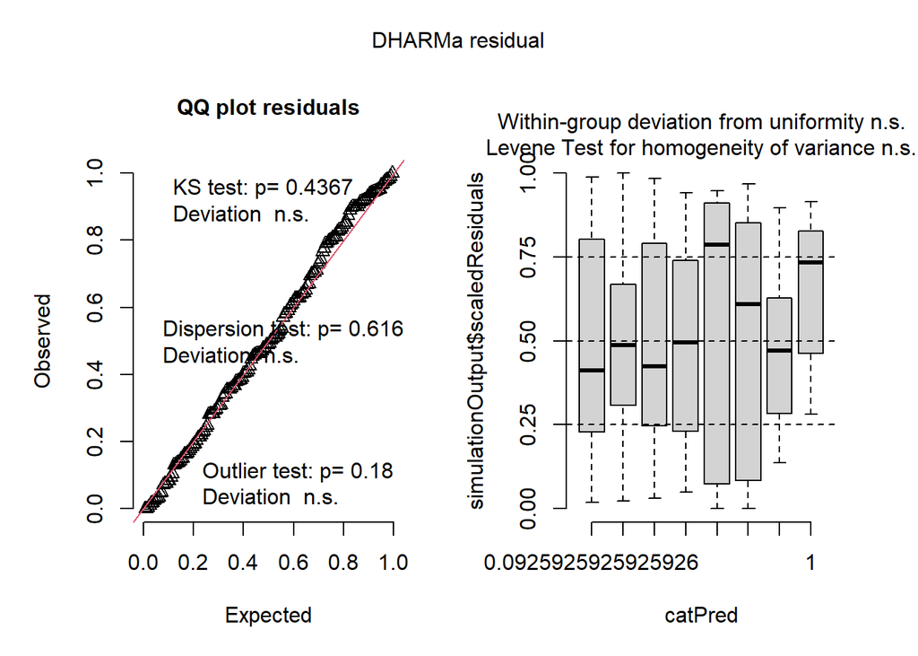

```r
library(DHARMa)

simulationOutput <- simulateResiduals(fittedModel = result3, plot = F)

plot(simulationOutput)
```

```r
citation("DHARMa")
```

```
##
##
##   Florian Hartig (2022). DHARMa: Residual Diagnostics for Hierarchical
##   (Multi-Level / Mixed) Regression Models. R package version 0.4.5.
##   https://CRAN.R-project.org/package=DHARMa
##
## A BibTeX entry for LaTeX users is
##
##   @Manual{,
##     title = {DHARMa: Residual Diagnostics for Hierarchical (Multi-Level / Mixed)
## Regression Models},
##     author = {Florian Hartig},
##     year = {2022},
##     note = {R package version 0.4.5},
##     url = {https://CRAN.R-project.org/package=DHARMa},
##   }
```

```r
rm(list = ls())
```

# Analyses Adjusted for ASD

### CBCL Externalising Adjusting for ASD

#### Descriptives

| asdcase | group | time | n | mean | sd | median | min | max |
| --- | --- | --- | --- | --- | --- | --- | --- | --- |
| 0 | 1 | 1 | 24 | 18.67572 | 9.395495 | 17.50000 | 5.217391 | 41.00000 |
| 0 | 1 | 2 | 18 | 11.88889 | 7.258981 | 10.00000 | 3.000000 | 32.00000 |
| 0 | 1 | 3 | 13 | 11.23077 | 7.715286 | 10.00000 | 1.000000 | 28.00000 |
| 0 | 2 | 1 | 25 | 23.86678 | 8.451321 | 23.00000 | 9.000000 | 41.00000 |
| 0 | 2 | 2 | 11 | 18.77686 | 8.152104 | 18.00000 | 6.545454 | 40.00000 |
| 0 | 2 | 3 | 5 | 15.60000 | 3.507136 | 16.00000 | 12.000000 | 21.00000 |
| 0 | 3 | 1 | 22 | 20.08365 | 9.325746 | 20.72050 | 3.000000 | 38.00000 |
| 0 | 3 | 2 | 20 | 18.31478 | 9.049999 | 18.00000 | 5.000000 | 40.00000 |
| 0 | 3 | 3 | 0 | NaN | NA | NA | Inf | -Inf |
| 1 | 1 | 1 | 6 | 25.78986 | 13.597465 | 27.00000 | 2.000000 | 41.73913 |
| 1 | 1 | 2 | 5 | 17.06087 | 11.789690 | 16.00000 | 6.000000 | 35.00000 |
| 1 | 1 | 3 | 5 | 22.13043 | 11.385453 | 20.00000 | 9.000000 | 39.65217 |
| 1 | 2 | 1 | 3 | 26.00000 | 12.288206 | 31.00000 | 12.000000 | 35.00000 |
| 1 | 2 | 2 | 2 | 22.80435 | 22.350723 | 22.80435 | 7.000000 | 38.60870 |
| 1 | 2 | 3 | 0 | NaN | NA | NA | Inf | -Inf |
| 1 | 3 | 1 | 4 | 18.00000 | 11.430952 | 19.00000 | 4.000000 | 30.00000 |
| 1 | 3 | 2 | 2 | 16.00000 | 8.485281 | 16.00000 | 10.000000 | 22.00000 |
| 1 | 3 | 3 | 0 | NaN | NA | NA | Inf | -Inf |

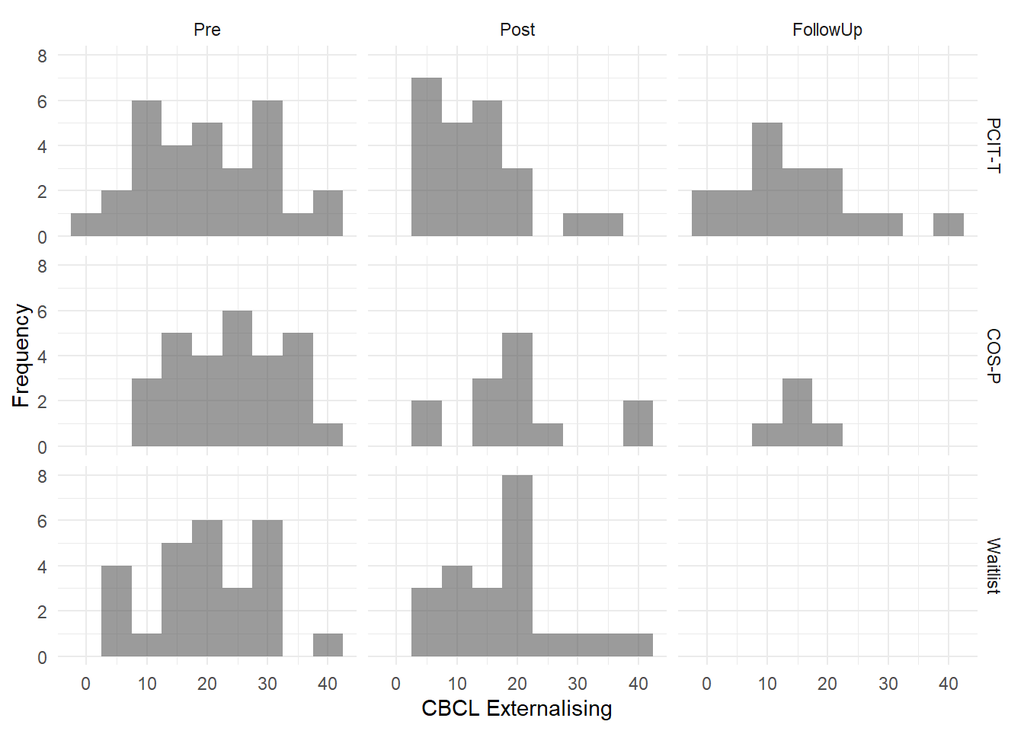

#### Model & Results

A linear mixed model with random effect for individual and fixed effects of group, time and the interaction was run. ASD status was then entered into the model as a main effect and then the 3-way interaction. Estimated marginal means were obtained, and contrasts specified to test Hypothesis 1 and Hypothesis 2.

```
## fixed-effect model matrix is rank deficient so dropping 1 column / coefficient
```

```
## fixed-effect model matrix is rank deficient so dropping 3 columns / coefficients
```

```
## refitting model(s) with ML (instead of REML)
```

|  | Effect | npar | AIC | BIC | logLik | deviance | Chisq | Df | Pr(>Chisq) |
| --- | --- | --- | --- | --- | --- | --- | --- | --- | --- |
| result0 | Intercept | 3 | 1179.966 | 1189.284 | -586.9829 | 1173.966 | NA | NA | NA |
| result0_5 | ASD | 4 | 1181.358 | 1193.781 | -586.6788 | 1173.358 | 0.6081769 | 1 | 0.4354751 |
| result1 | Group* Time*ASD | 6 | 1179.510 | 1198.145 | -583.7548 | 1167.510 | 5.8480371 | 2 | 0.0537174 |
| result2 | ASD + Group + Time | 8 | 1157.047 | 1181.895 | -570.5236 | 1141.047 | 26.4622714 | 2 | 0.0000018 |
| result3 | ASD + Group + Time + Group*Time | 11 | 1161.030 | 1195.195 | -569.5148 | 1139.030 | 2.0176089 | 3 | 0.5687600 |
| result4 | Group* Time*ASD | 17 | 1167.626 | 1220.427 | -566.8129 | 1133.626 | 5.4038367 | 6 | 0.4931547 |

There is no evidence that ASD moderates the 2-way group*time interaction the 3-way interaction (p=0.493).

Model3, the model with Group*Time, adjusted by ASD will be the model I use for Estimated Means.

```r
summary(result3)
```

```
## Linear mixed model fit by REML. t-tests use Satterthwaite's method [
## lmerModLmerTest]
## Formula: outcome ~ asdcase + group * time + (1 | id)
##    Data: dat
##
## REML criterion at convergence: 1112
##
## Scaled residuals:
##      Min       1Q   Median       3Q      Max
## -1.98112 -0.46812 -0.04667  0.50290  2.13941
##
## Random effects:
##  Groups   Name        Variance Std.Dev.
##  id       (Intercept) 61.47    7.840
##  Residual             26.23    5.122
## Number of obs: 165, groups:  id, 85
##
## Fixed effects:
##              Estimate Std. Error       df t value Pr(>|t|)
## (Intercept)   19.5456     1.7902  98.5354  10.918  < 2e-16 ***
## asdcase1       2.7646     2.6535  76.7769   1.042 0.300747
## group2         4.2535     2.4731 100.5972   1.720 0.088520 .
## group3         0.4161     2.5005 102.2095   0.166 0.868177
## time2         -5.9464     1.4792  77.6608  -4.020 0.000134 ***
## time3         -4.9961     1.6241  78.5864  -3.076 0.002885 **
## group2:time2   0.5317     2.4292  82.6386   0.219 0.827274
## group3:time2   2.8394     2.1439  77.9958   1.324 0.189235
## group2:time3  -0.3088     3.3035  83.0015  -0.093 0.925739
## ---
## Signif. codes:  0 '***' 0.001 '**' 0.01 '*' 0.05 '.' 0.1 ' ' 1
##
## Correlation of Fixed Effects:
##             (Intr) asdcs1 group2 group3 time2  time3  grp2:2 grp3:2
## asdcase1    -0.296
## group2      -0.690  0.100
## group3      -0.669  0.053  0.478
## time2       -0.328 -0.007  0.238  0.236
## time3       -0.294 -0.024  0.215  0.214  0.424
## group2:tim2  0.204 -0.011 -0.303 -0.145 -0.609 -0.258
## group3:tim2  0.219  0.029 -0.162 -0.357 -0.690 -0.293  0.420
## group2:tim3  0.141  0.022 -0.219 -0.105 -0.209 -0.492  0.338  0.144
## fit warnings:
## fixed-effect model matrix is rank deficient so dropping 1 column / coefficient
```

#### Estimated Means & Change

Estimated means for each Treatment and Time (adjusted by ASD status) are presented. In addition, within-group change between time points is presented with 95% CIs.

```
## group = 1:
##  time emmean   SE    df lower.CL upper.CL
##  1      20.9 1.89  98.4     17.2     24.7
##  2      15.0 2.00 114.2     11.0     18.9
##  3      15.9 2.10 128.1     11.8     20.1
##
## group = 2:
##  time emmean   SE    df lower.CL upper.CL
##  1      25.2 2.05  96.3     21.1     29.3
##  2      19.8 2.45 139.7     14.9     24.6
##  3      19.9 3.28 149.5     13.4     26.4
##
## group = 3:
##  time emmean   SE    df lower.CL upper.CL
##  1      21.3 2.04  99.3     17.3     25.4
##  2      18.2 2.14 112.5     14.0     22.5
##  3    nonEst   NA    NA       NA       NA
##
## Results are averaged over the levels of: asdcase
## Degrees-of-freedom method: kenward-roger
## Confidence level used: 0.95
```

```
## group = 1:
##  contrast estimate   SE   df lower.CL upper.CL
##  1 - 2        5.95 1.48 80.0    2.409     9.48
##  1 - 3        5.00 1.63 80.9    1.112     8.88
##  2 - 3       -0.95 1.67 77.9   -4.943     3.04
##
## group = 2:
##  contrast estimate   SE   df lower.CL upper.CL
##  1 - 2        5.41 1.93 88.0    0.805    10.02
##  1 - 3        5.30 2.89 86.8   -1.577    12.19
##  2 - 3       -0.11 2.94 80.8   -7.124     6.90
##
## group = 3:
##  contrast estimate   SE   df lower.CL upper.CL
##  1 - 2        3.11 1.55 80.7   -0.603     6.82
##  1 - 3      nonEst   NA   NA       NA       NA
##  2 - 3      nonEst   NA   NA       NA       NA
##
## Results are averaged over the levels of: asdcase
## Degrees-of-freedom method: kenward-roger
## Confidence level used: 0.95
## Conf-level adjustment: tukey method for comparing a family of 3 estimates
```

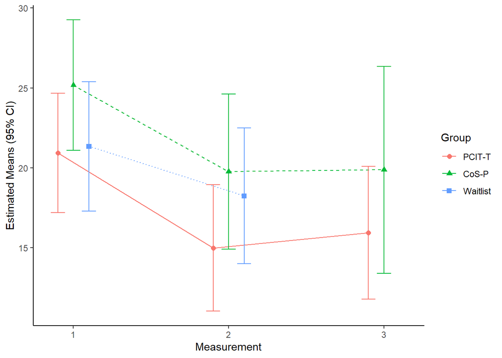

#### Hypothesis 1

We hypothesize that from baseline (‘T1’) to post-treatment/waitlist (‘T2’) there will be a gradient effect, whereby parent-child dyads who receive PCIT-T will show the greatest gains and parent-child dyads who receive no treatment will show the least gains. For the outcome, then, the null hypothesis is:

$H_0: \text {mean change}(\text{PCIT-T}) = \text {mean change}(\text{CoS-P}) = \text {mean change}(\text{Waitlist})$ $H_A: \text {mean change}(\text{PCIT-T}) > \text {mean change}(\text{CoS-P}) > \text {mean change}(\text{Waitlist})$

This is a joint hypothesis test.

First, confirming that the ordering of the means is as hypothesized:

```
## group = 1:
##  contrast estimate   SE   df t.ratio p.value
##  1 - 2        5.95 1.48 80.0   4.015  0.0004
##  1 - 3        5.00 1.63 80.9   3.071  0.0081
##  2 - 3       -0.95 1.67 77.9  -0.569  0.8371
##
## group = 2:
##  contrast estimate   SE   df t.ratio p.value
##  1 - 2        5.41 1.93 88.0   2.800  0.0171
##  1 - 3        5.30 2.89 86.8   1.838  0.1633
##  2 - 3       -0.11 2.94 80.8  -0.037  0.9992
##
## group = 3:
##  contrast estimate   SE   df t.ratio p.value
##  1 - 2        3.11 1.55 80.7   2.000  0.1188
##  1 - 3      nonEst   NA   NA      NA      NA
##  2 - 3      nonEst   NA   NA      NA      NA
##
## Results are averaged over the levels of: asdcase
## Degrees-of-freedom method: kenward-roger
## P value adjustment: tukey method for comparing a family of 3 estimates
```

So, the mean change for PCITT > COSP > Waitlist.

Now, to get the p-value associated with the joint hypothesis.

```
##   (Intercept) asdcase1 group2 group3 time2 time3 group2:time2 group3:time2
## 1           0        0      0      0     0     0           -1            0
## 2           0        0      0      0     0     1            0            1
##   group2:time3
## 1            0
## 2            0
```

```
##
##   General Linear Hypotheses
##
## Linear Hypotheses:
##        Estimate
## 1 == 0  -0.5317
## 2 == 0  -2.1567
##
## Global Test:
##        F DF1 DF2 Pr(>F)
## 1 0.5397   2 154  0.584
```

p>0.05, so this joint null hypothesis is not rejected.

#### Hypothesis 2

There will be a gradient of size of change from T2 to T3 such that the change in the PCIT-T group > the change in the CoS-P group. This isn’t really a gradient; it’s just 1 hypothesis.

First, the change in PCITT and COSP from time 2 to time 3:

```
## group = 1:
##  contrast estimate   SE   df t.ratio p.value
##  1 - 2        5.95 1.48 80.0   4.015  0.0004
##  1 - 3        5.00 1.63 80.9   3.071  0.0081
##  2 - 3       -0.95 1.67 77.9  -0.569  0.8371
##
## group = 2:
##  contrast estimate   SE   df t.ratio p.value
##  1 - 2        5.41 1.93 88.0   2.800  0.0171
##  1 - 3        5.30 2.89 86.8   1.838  0.1633
##  2 - 3       -0.11 2.94 80.8  -0.037  0.9992
##
## group = 3:
##  contrast estimate   SE   df t.ratio p.value
##  1 - 2        3.11 1.55 80.7   2.000  0.1188
##  1 - 3      nonEst   NA   NA      NA      NA
##  2 - 3      nonEst   NA   NA      NA      NA
##
## Results are averaged over the levels of: asdcase
## Degrees-of-freedom method: kenward-roger
## P value adjustment: tukey method for comparing a family of 3 estimates
```

```
##
##   Simultaneous Tests for General Linear Hypotheses
##
## Fit: lmer(formula = outcome ~ asdcase + group * time + (1 | id), data = dat)
##
## Linear Hypotheses:
##        Estimate Std. Error z value Pr(>|z|)
## 1 == 0  -0.8406     3.3752  -0.249    0.803
## (Adjusted p values reported -- single-step method)
```

p>0.05, so we do not have enough evidence to suggest that the change from t2 to t3 in PCITT is greater than the change in COSP, adjusting for ASD diagnosis.

#### Residuals

Assumptions of the model are met.

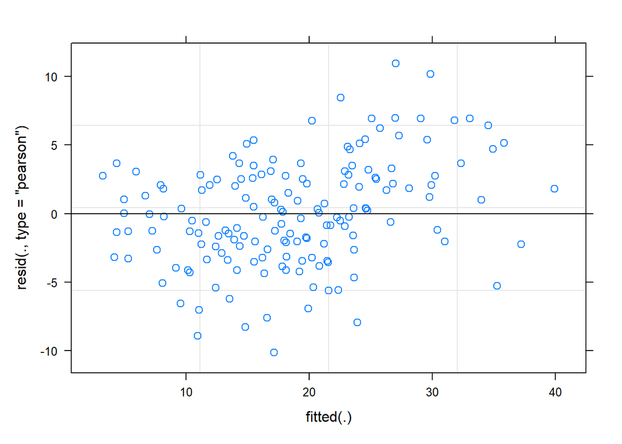

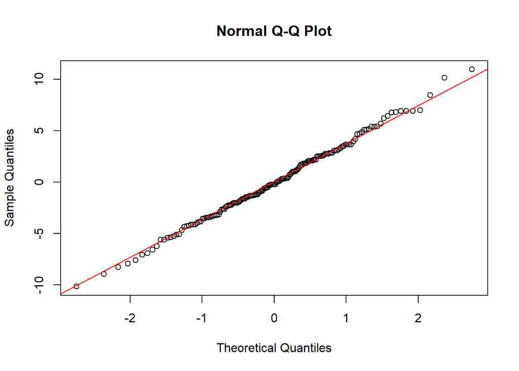

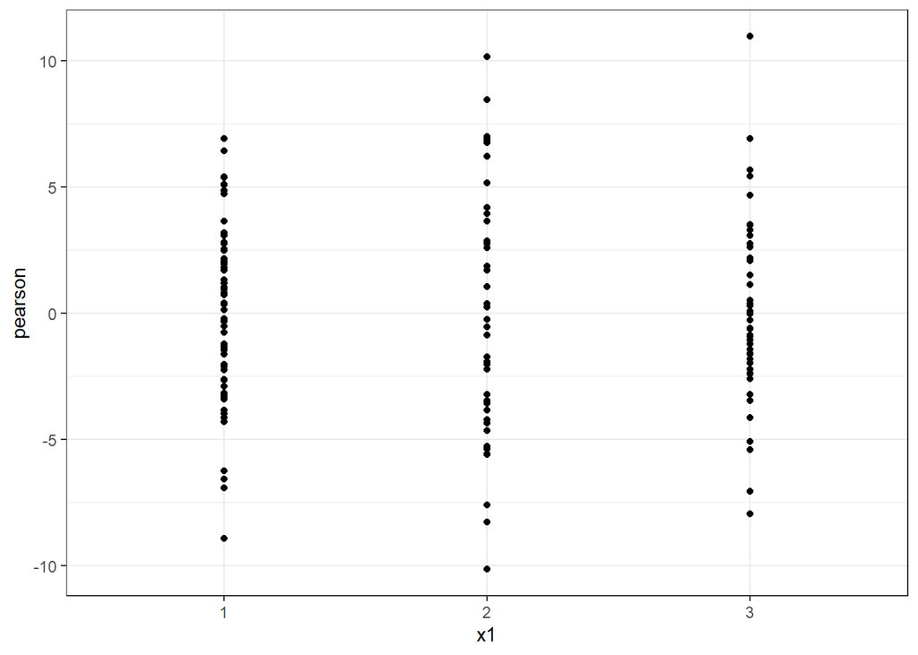

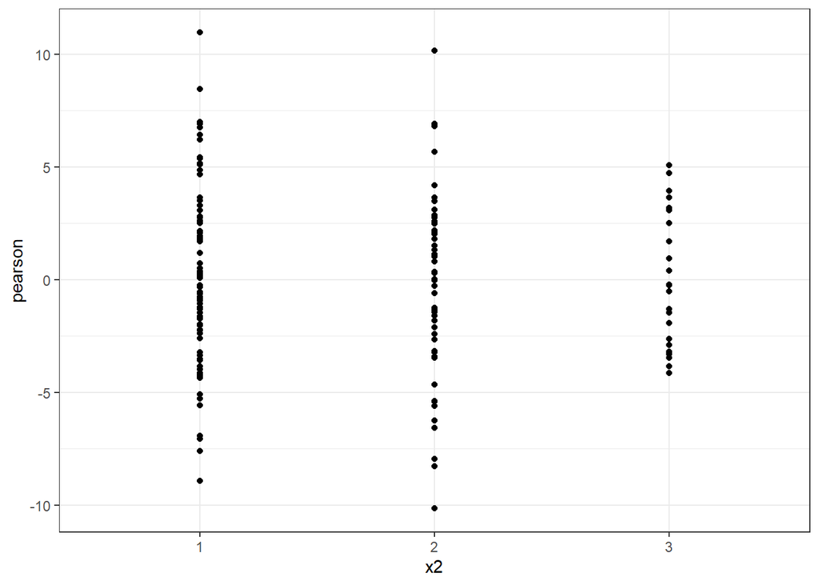

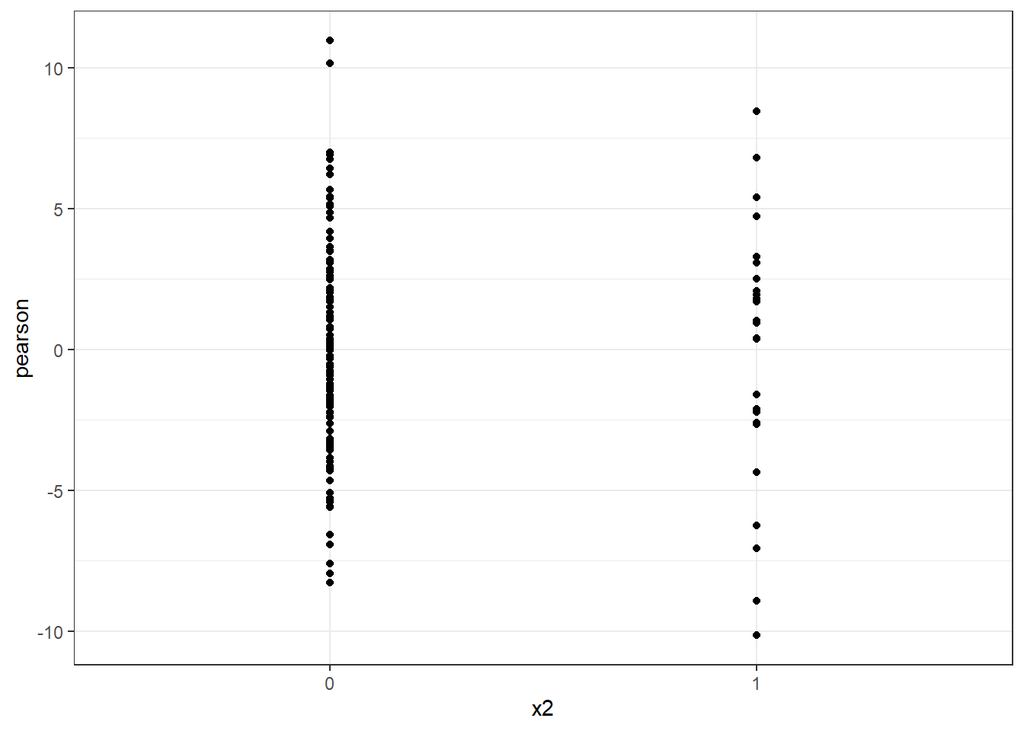

```r
rm(list = ls())
```

### CBCL Internalising Adjusting for ASD

#### Descriptives

| asdcase | group | time | n | mean | sd | median | min | max |
| --- | --- | --- | --- | --- | --- | --- | --- | --- |
| 0 | 1 | 1 | 24 | 11.345588 | 8.424163 | 9.500000 | 1.000000 | 37 |
| 0 | 1 | 2 | 18 | 5.833333 | 4.913966 | 4.500000 | 0.000000 | 19 |
| 0 | 1 | 3 | 13 | 7.076923 | 5.559699 | 8.000000 | 0.000000 | 19 |
| 0 | 2 | 1 | 25 | 12.946000 | 6.135449 | 13.000000 | 2.250000 | 24 |
| 0 | 2 | 2 | 11 | 11.090909 | 5.557959 | 10.000000 | 4.000000 | 20 |
| 0 | 2 | 3 | 5 | 9.200000 | 8.136338 | 5.000000 | 2.000000 | 19 |
| 0 | 3 | 1 | 22 | 10.452101 | 5.879217 | 9.264706 | 1.000000 | 20 |
| 0 | 3 | 2 | 20 | 10.200000 | 8.364084 | 9.000000 | 1.000000 | 36 |
| 0 | 3 | 3 | 0 | NaN | NA | NA | Inf | -Inf |
| 1 | 1 | 1 | 6 | 17.552381 | 10.683769 | 19.000000 | 3.085714 | 29 |
| 1 | 1 | 2 | 5 | 14.600000 | 9.964939 | 10.000000 | 7.000000 | 31 |
| 1 | 1 | 3 | 5 | 15.868571 | 8.635513 | 14.000000 | 5.000000 | 28 |
| 1 | 2 | 1 | 3 | 30.666667 | 11.372481 | 34.000000 | 18.000000 | 40 |
| 1 | 2 | 2 | 2 | 25.500000 | 26.162951 | 25.500000 | 7.000000 | 44 |
| 1 | 2 | 3 | 0 | NaN | NA | NA | Inf | -Inf |
| 1 | 3 | 1 | 4 | 16.500000 | 7.047458 | 15.500000 | 9.000000 | 26 |
| 1 | 3 | 2 | 2 | 19.000000 | 4.242641 | 19.000000 | 16.000000 | 22 |
| 1 | 3 | 3 | 0 | NaN | NA | NA | Inf | -Inf |

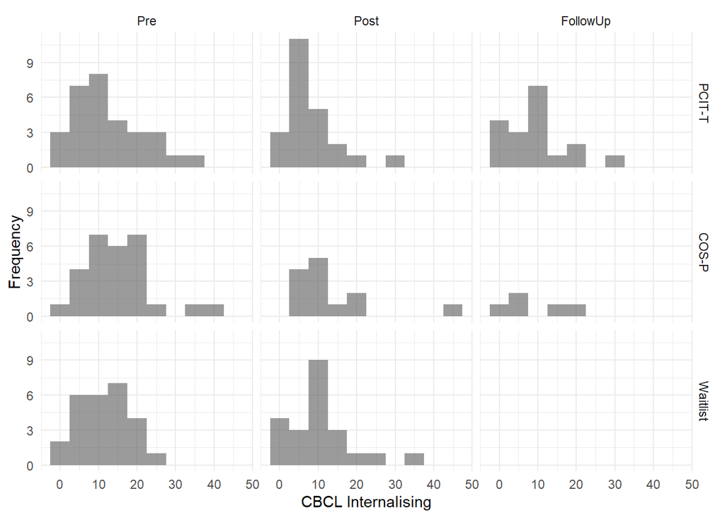

#### Model & Results

A linear mixed model with random effect for individual and fixed effects of group, time and the interaction was run. ASD status was then entered into the model as a main effect and then the 3-way interaction. Estimated marginal means were obtained, and contrasts specified to test Hypothesis 1 and Hypothesis 2.

```
## fixed-effect model matrix is rank deficient so dropping 1 column / coefficient
```

```
## fixed-effect model matrix is rank deficient so dropping 3 columns / coefficients
```

This is the ANOVA table for the model. p-values are likelihood ratio tests for adding the new term to the model just before. A p-value <0.05 indicates that adding that term results in better model fit. The most important p-value is the interaction p-value.

```
## refitting model(s) with ML (instead of REML)
```

|  | Effect | npar | AIC | BIC | logLik | deviance | Chisq | Df | Pr(>Chisq) |
| --- | --- | --- | --- | --- | --- | --- | --- | --- | --- |
| result0 | Intercept | 3 | 1115.864 | 1125.182 | -554.9322 | 1109.864 | NA | NA | NA |
| result0_5 | ASD | 4 | 1104.414 | 1116.838 | -548.2071 | 1096.414 | 13.450189 | 1 | 0.0002450 |
| result1 | Group* Time*ASD | 6 | 1103.318 | 1121.954 | -545.6592 | 1091.318 | 5.095847 | 2 | 0.0782440 |
| result2 | ASD + Group + Time | 8 | 1093.117 | 1117.965 | -538.5586 | 1077.117 | 14.201290 | 2 | 0.0008246 |
| result3 | ASD + Group + Time + Group*Time | 11 | 1095.279 | 1129.444 | -536.6394 | 1073.279 | 3.838410 | 3 | 0.2794500 |
| result4 | Group* Time*ASD | 17 | 1099.050 | 1151.851 | -532.5251 | 1065.050 | 8.228505 | 6 | 0.2218359 |

There is no evidence that ASD moderates the 2-way group*time interaction the 3-way interaction (p=0.222).

Model3, the model with Group*Time, adjusted by ASD will be the model I use for Estimated Means.

```r
summary(result3)
```

```
## Linear mixed model fit by REML. t-tests use Satterthwaite's method [
## lmerModLmerTest]
## Formula: outcome ~ asdcase + group * time + (1 | id)
##    Data: dat
##
## REML criterion at convergence: 1049.9
##
## Scaled residuals:
##      Min       1Q   Median       3Q      Max
## -2.93941 -0.42373 -0.06427  0.35472  2.85702
##
## Random effects:
##  Groups   Name        Variance Std.Dev.
##  id       (Intercept) 40.84    6.391
##  Residual             17.74    4.211
## Number of obs: 165, groups:  id, 85
##
## Fixed effects:
##               Estimate Std. Error        df t value Pr(>|t|)
## (Intercept)   10.81236    1.46303  96.85392   7.390 5.21e-11 ***
## asdcase1       8.87293    2.16669  74.63556   4.095 0.000106 ***
## group2         3.08161    2.02121  98.97490   1.525 0.130539
## group3        -0.08552    2.04376 100.62513  -0.042 0.966707
## time2         -4.28243    1.21605  75.62071  -3.522 0.000731 ***
## time3         -3.18831    1.33517  76.56411  -2.388 0.019408 *
## group2:time2   1.69379    1.99664  80.66480   0.848 0.398769
## group3:time2   3.10307    1.76249  75.95761   1.761 0.082328 .
## group2:time3  -1.11568    2.71522  81.05442  -0.411 0.682231
## ---
## Signif. codes:  0 '***' 0.001 '**' 0.01 '*' 0.05 '.' 0.1 ' ' 1
##
## Correlation of Fixed Effects:
##             (Intr) asdcs1 group2 group3 time2  time3  grp2:2 grp3:2
## asdcase1    -0.296
## group2      -0.690  0.100
## group3      -0.669  0.053  0.478
## time2       -0.330 -0.007  0.240  0.238
## time3       -0.296 -0.024  0.217  0.215  0.424
## group2:tim2  0.206 -0.011 -0.305 -0.145 -0.609 -0.258
## group3:tim2  0.221  0.029 -0.163 -0.359 -0.690 -0.293  0.420
## group2:tim3  0.142  0.022 -0.221 -0.105 -0.209 -0.492  0.338  0.144
## fit warnings:
## fixed-effect model matrix is rank deficient so dropping 1 column / coefficient
```

#### Estimated Means & Change

Estimated means for each Treatment and Time (adjusted by ASD status) are presented. In addition, within-group change between time points is presented with 95% CIs.

```
## group = 1:
##  time emmean   SE    df lower.CL upper.CL
##  1      15.2 1.54  98.6    12.19     18.3
##  2      11.0 1.63 114.5     7.73     14.2
##  3      12.1 1.71 128.5     8.67     15.5
##
## group = 2:
##  time emmean   SE    df lower.CL upper.CL
##  1      18.3 1.68  96.6    15.00     21.7
##  2      15.7 2.01 140.0    11.78     19.7
##  3      14.0 2.69 149.2     8.72     19.3
##
## group = 3:
##  time emmean   SE    df lower.CL upper.CL
##  1      15.2 1.67  99.6    11.85     18.5
##  2      14.0 1.75 112.9    10.51     17.5
##  3    nonEst   NA    NA       NA       NA
##
## Results are averaged over the levels of: asdcase
## Degrees-of-freedom method: kenward-roger
## Confidence level used: 0.95
```

```
## group = 1:
##  contrast estimate   SE   df lower.CL upper.CL
##  1 - 2        4.28 1.22 80.0  1.37467     7.19
##  1 - 3        3.19 1.34 81.0 -0.00467     6.38
##  2 - 3       -1.09 1.37 78.0 -4.37698     2.19
##
## group = 2:
##  contrast estimate   SE   df lower.CL upper.CL
##  1 - 2        2.59 1.59 88.1 -1.19992     6.38
##  1 - 3        4.30 2.37 87.0 -1.35187     9.96
##  2 - 3        1.72 2.42 80.9 -4.05087     7.48
##
## group = 3:
##  contrast estimate   SE   df lower.CL upper.CL
##  1 - 2        1.18 1.28 80.8 -1.87045     4.23
##  1 - 3      nonEst   NA   NA       NA       NA
##  2 - 3      nonEst   NA   NA       NA       NA
##
## Results are averaged over the levels of: asdcase
## Degrees-of-freedom method: kenward-roger
## Confidence level used: 0.95
## Conf-level adjustment: tukey method for comparing a family of 3 estimates
```

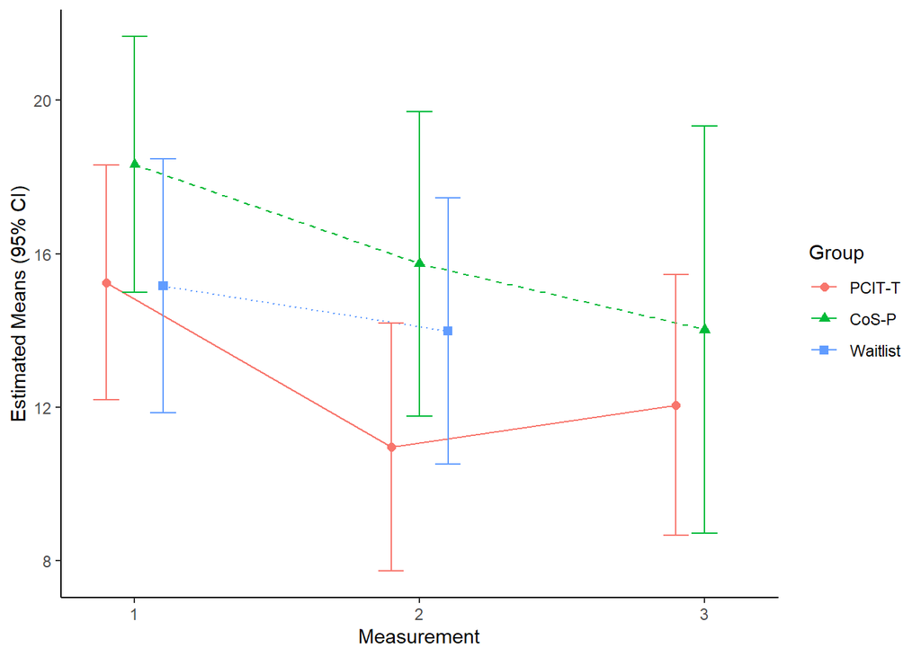

#### Hypothesis 1

We hypothesize that from baseline (‘T1’) to post-treatment/waitlist (‘T2’) there will be a gradient effect, whereby parent-child dyads who receive PCIT-T will show the greatest gains and parent-child dyads who receive no treatment will show the least gains. For the outcome, then, the null hypothesis is:

$H_0: \text {mean change}(\text{PCIT-T}) = \text {mean change}(\text{CoS-P}) = \text {mean change}(\text{Waitlist})$ $H_A: \text {mean change}(\text{PCIT-T}) > \text {mean change}(\text{CoS-P}) > \text {mean change}(\text{Waitlist})$

This is a joint hypothesis test.

First, confirming that the ordering of the means is as hypothesized:

```
## group = 1:
##  contrast estimate   SE   df t.ratio p.value
##  1 - 2        4.28 1.22 80.0   3.517  0.0021
##  1 - 3        3.19 1.34 81.0   2.384  0.0504
##  2 - 3       -1.09 1.37 78.0  -0.796  0.7064
##
## group = 2:
##  contrast estimate   SE   df t.ratio p.value
##  1 - 2        2.59 1.59 88.1   1.629  0.2390
##  1 - 3        4.30 2.37 87.0   1.815  0.1708
##  2 - 3        1.72 2.42 80.9   0.710  0.7581
##
## group = 3:
##  contrast estimate   SE   df t.ratio p.value
##  1 - 2        1.18 1.28 80.8   0.923  0.6272
##  1 - 3      nonEst   NA   NA      NA      NA
##  2 - 3      nonEst   NA   NA      NA      NA
##
## Results are averaged over the levels of: asdcase
## Degrees-of-freedom method: kenward-roger
## P value adjustment: tukey method for comparing a family of 3 estimates
```

So, the mean change for PCITT > COSP > Waitlist.

Now, to get the p-value associated with the joint hypothesis.

```
##   (Intercept) asdcase1 group2 group3 time2 time3 group2:time2 group3:time2
## 1           0        0      0      0     0     0            1            0
## 2           0        0      0      0     0     0           -1            1
##   group2:time3
## 1            0
## 2            0
```

```
##
##   General Linear Hypotheses
##
## Linear Hypotheses:
##        Estimate
## 1 == 0    1.694
## 2 == 0    1.409
##
## Global Test:
##       F DF1 DF2 Pr(>F)
## 1 1.557   2 154  0.214
```

p>0.05, so this joint hypothesis is not supported.

#### Hypothesis 2

There will be a gradient of size of change from T2 to T3 such that the change in the PCIT-T group > the change in the CoS-P group. This isn’t really a gradient; it’s just 1 hypothesis.

First, the change in PCITT and COSP from time 2 to time 3:

```
## group = 1:
##  contrast estimate   SE   df t.ratio p.value
##  1 - 2        4.28 1.22 80.0   3.517  0.0021
##  1 - 3        3.19 1.34 81.0   2.384  0.0504
##  2 - 3       -1.09 1.37 78.0  -0.796  0.7064
##
## group = 2:
##  contrast estimate   SE   df t.ratio p.value
##  1 - 2        2.59 1.59 88.1   1.629  0.2390
##  1 - 3        4.30 2.37 87.0   1.815  0.1708
##  2 - 3        1.72 2.42 80.9   0.710  0.7581
##
## group = 3:
##  contrast estimate   SE   df t.ratio p.value
##  1 - 2        1.18 1.28 80.8   0.923  0.6272
##  1 - 3      nonEst   NA   NA      NA      NA
##  2 - 3      nonEst   NA   NA      NA      NA
##
## Results are averaged over the levels of: asdcase
## Degrees-of-freedom method: kenward-roger
## P value adjustment: tukey method for comparing a family of 3 estimates
```

There is not greater change (decreasing score) in PCITT( 3.19) than in COSP (4.3)

```
##
##   Simultaneous Tests for General Linear Hypotheses
##
## Fit: lmer(formula = outcome ~ asdcase + group * time + (1 | id), data = dat)
##
## Linear Hypotheses:
##        Estimate Std. Error z value Pr(>|z|)
## 1 == 0   -2.809      2.775  -1.012    0.311
## (Adjusted p values reported -- single-step method)
```

p>0.05, so we do not have enough evidence to suggest that the change from t2 to t3 in PCITT is greater than the change in COSP, adjusting for ASD diagnosis.

#### Residuals

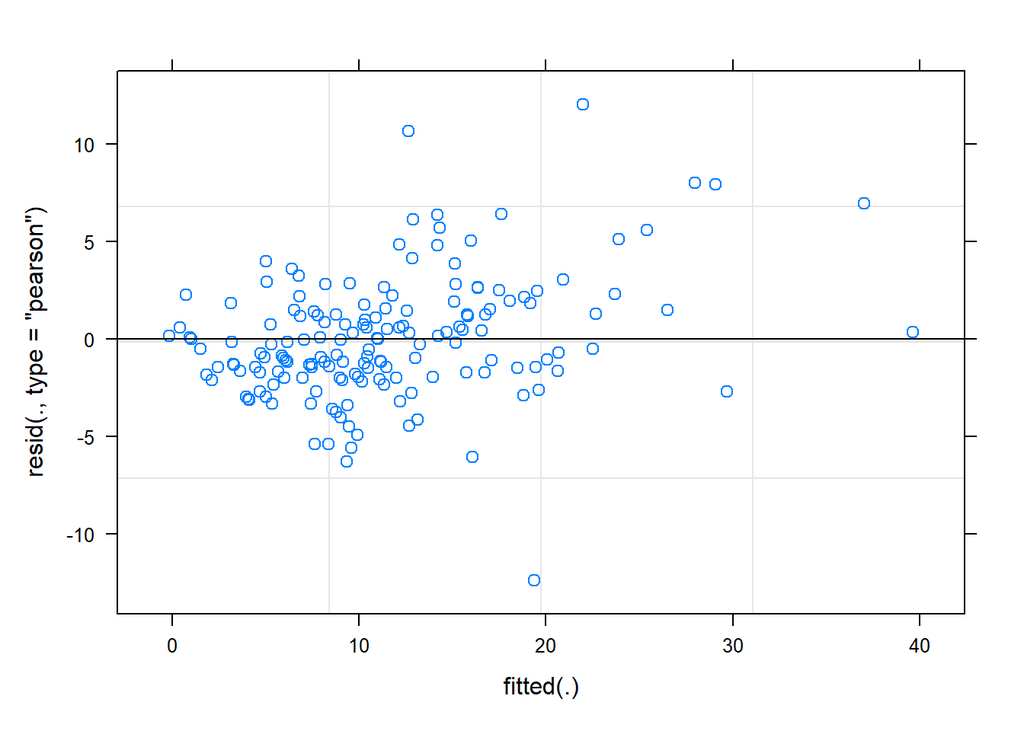

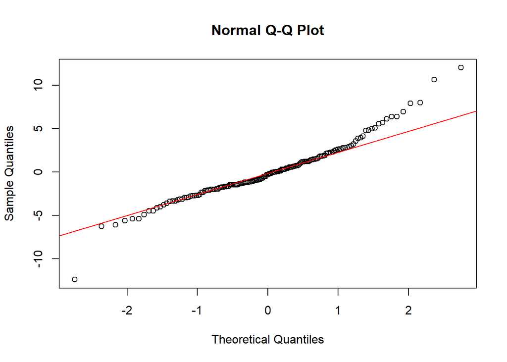

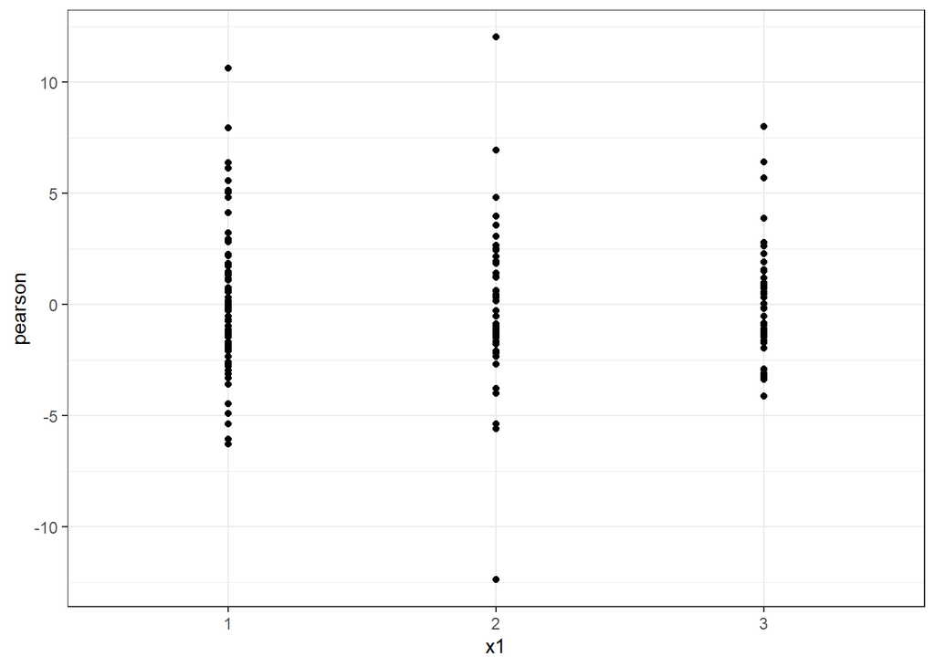

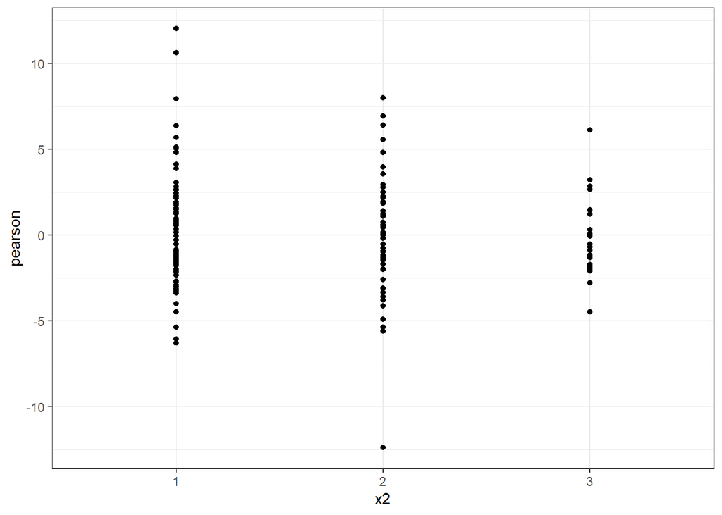

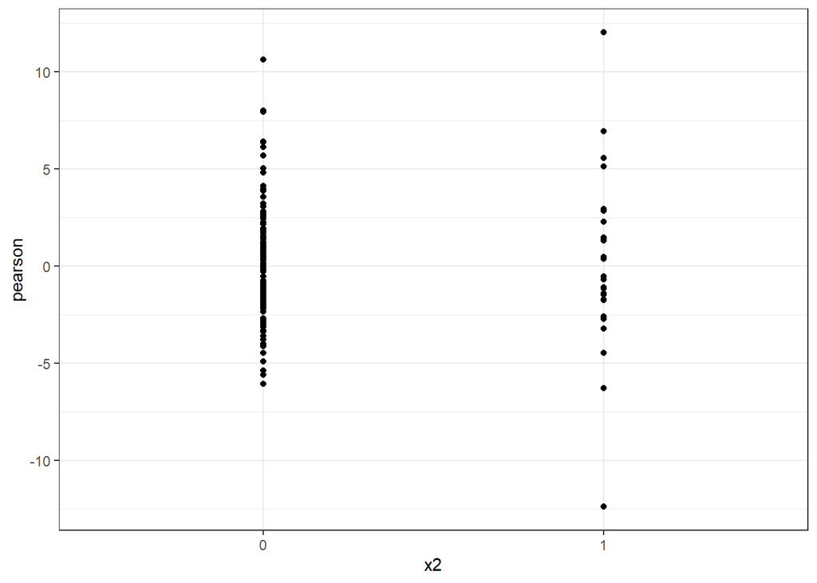

```r
rm(list = ls())
```

### DPICS LP Controlling for ASD

#### Descriptives

| asdcase | group | time | n | mean | sd | median | min | max |
| --- | --- | --- | --- | --- | --- | --- | --- | --- |
| 0 | 1 | 1 | 24 | 0.2763600 | 0.3372033 | 0.2153055 | 0.0000000 | 1.2145749 |
| 0 | 1 | 2 | 18 | 5.6240788 | 2.8478944 | 6.1167987 | 1.0060362 | 11.4503817 |
| 0 | 1 | 3 | 13 | 3.7159787 | 3.6368663 | 2.6315789 | 0.8032129 | 14.1479100 |
| 0 | 2 | 1 | 26 | 0.4254960 | 0.7155031 | 0.0000000 | 0.0000000 | 2.7848101 |
| 0 | 2 | 2 | 10 | 0.7359291 | 0.9247548 | 0.4459375 | 0.0000000 | 2.9702970 |
| 0 | 2 | 3 | 5 | 0.3891770 | 0.2192215 | 0.3690037 | 0.1715266 | 0.7352941 |
| 0 | 3 | 1 | 25 | 0.4939211 | 0.7660869 | 0.0000000 | 0.0000000 | 2.9629630 |
| 0 | 3 | 2 | 22 | 0.5452864 | 0.7182053 | 0.2719907 | 0.0000000 | 2.9197080 |
| 0 | 3 | 3 | 1 | 1.2704174 | NA | 1.2704174 | 1.2704174 | 1.2704174 |
| 1 | 1 | 1 | 6 | 0.0000000 | 0.0000000 | 0.0000000 | 0.0000000 | 0.0000000 |
| 1 | 1 | 2 | 4 | 5.1518429 | 1.0341079 | 5.0198043 | 4.0609137 | 6.5068493 |
| 1 | 1 | 3 | 5 | 2.5407338 | 1.9919300 | 1.6025641 | 0.3012048 | 4.8543689 |
| 1 | 2 | 1 | 3 | 0.0000000 | 0.0000000 | 0.0000000 | 0.0000000 | 0.0000000 |
| 1 | 2 | 2 | 2 | 0.3393665 | 0.4799367 | 0.3393665 | 0.0000000 | 0.6787330 |
| 1 | 2 | 3 | 0 | NaN | NA | NA | Inf | -Inf |
| 1 | 3 | 1 | 5 | 0.2283082 | 0.3661509 | 0.0000000 | 0.0000000 | 0.8403361 |
| 1 | 3 | 2 | 4 | 0.5338078 | 1.0676157 | 0.0000000 | 0.0000000 | 2.1352313 |
| 1 | 3 | 3 | 0 | NaN | NA | NA | Inf | -Inf |

Note that with the number of ASD cases, it is unliekly that a model with the group*time* ASD interction will run at all.

#### Model & Results

A generalized linear mixed model (GLMM) with random effect for individual and fixed effects of group, time and ASD and the interaction was run on the number of LP responses in the total number of verbalizations. A binomial distribution was specifed with a logit link. Estimated marginal means were obtained, and contrasts specified to test Hypothesis 1 and Hypothesis 2. Assumptions on the residuals were examined using simulated residuals (see below).

```
## fixed-effect model matrix is rank deficient so dropping 1 column / coefficient
```

The model with asdcase*group*time does not converge. We will leave it out.

```r
result4<-glmer(cbind(lp, verbal-lp) ~ asdcase*group*time + (1 | id), data=p, family=binomial)
```

```
## fixed-effect model matrix is rank deficient so dropping 3 columns / coefficients
```

This is the ANOVA table for the model. p-values are likelihood ratio tests for adding the new term to the model just before. A p-value <0.05 indicates that adding that term results in better model fit.

|  | Effect | npar | AIC | BIC | logLik | deviance | Chisq | Df | Pr(>Chisq) |
| --- | --- | --- | --- | --- | --- | --- | --- | --- | --- |
| result0 | Intercept | 2 | 1269.8559 | 1276.1509 | -632.9279 | 1265.8559 | NA | NA | NA |
| result0_5 | ASD | 3 | 1271.5224 | 1280.9649 | -632.7612 | 1265.5224 | 0.3335152 | 1 | 0.5635965 |
| result1 | ASD + Group | 5 | 1243.7262 | 1259.4637 | -616.8631 | 1233.7262 | 31.7961803 | 2 | 0.0000001 |
| result2 | ASD + Group + Time | 7 | 875.4004 | 897.4328 | -430.7002 | 861.4004 | 372.3258246 | 2 | 0.0000000 |
| result3 | ASD + Group*Time | 10 | 742.0867 | 773.5617 | -361.0434 | 722.0867 | 139.3136274 | 3 | 0.0000000 |

```r
summary(result3)
```

```
## Generalized linear mixed model fit by maximum likelihood (Laplace
##   Approximation) [glmerMod]
##  Family: binomial  ( logit )
## Formula: cbind(lp, verbal - lp) ~ asdcase + group + time + group * time +
##     (1 | id)
##    Data: p
##
##      AIC      BIC   logLik deviance df.resid
##    742.1    773.6   -361.0    722.1      162
##
## Scaled residuals:
##     Min      1Q  Median      3Q     Max
## -1.9733 -0.7089 -0.4152  0.5031  3.9746
##
## Random effects:
##  Groups Name        Variance Std.Dev.
##  id     (Intercept) 0.917    0.9576
## Number of obs: 172, groups:  id, 89
##
## Fixed effects:
##              Estimate Std. Error z value Pr(>|z|)
## (Intercept)   -6.2855     0.2877 -21.846  < 2e-16 ***
## asdcase1      -0.5584     0.3619  -1.543    0.123
## group2         0.2570     0.3879   0.662    0.508
## group3         0.3834     0.3790   1.012    0.312
## time2          3.2864     0.2307  14.245  < 2e-16 ***
## time3          2.7556     0.2377  11.595  < 2e-16 ***
## group2:time2  -2.8562     0.3487  -8.191 2.60e-16 ***
## group3:time2  -3.1029     0.3135  -9.897  < 2e-16 ***
## group2:time3  -2.2824     0.5393  -4.232 2.32e-05 ***
## ---
## Signif. codes:  0 '***' 0.001 '**' 0.01 '*' 0.05 '.' 0.1 ' ' 1
##
## Correlation of Fixed Effects:
##             (Intr) asdcs1 group2 group3 time2  time3  grp2:2 grp3:2
## asdcase1    -0.220
## group2      -0.714  0.110
## group3      -0.719  0.053  0.564
## time2       -0.685 -0.021  0.511  0.524
## time3       -0.663 -0.030  0.496  0.509  0.924
## group2:tim2  0.456  0.007 -0.501 -0.344 -0.661 -0.611
## group3:tim2  0.502  0.031 -0.372 -0.573 -0.736 -0.680  0.487
## group2:tim3  0.285  0.023 -0.372 -0.235 -0.408 -0.442  0.428  0.299
## fit warnings:
## fixed-effect model matrix is rank deficient so dropping 1 column / coefficient
```

#### Estimated Means & Change

Estimated means for each Treatment and Time are presented. In addition, within-group change between time points is presented with 95% CIs.

```r
# type="response" means that the emms are transformed and presented on the orginal scale
# This website has a nice demonstration of emmeans with GLMM https://cran.r-project.org/web/packages/emmeans/vignettes/transformations.html

result.change  <- emmeans(result3, "time", by = "group", type = "response")
# Differences give ODDS RATIOS
result.change.d <-pairs(result.change)
summary(result.change)
```

```
## group = 1:
##  time    prob       SE  df asymp.LCL asymp.UCL
##  1    0.00141 0.000428 Inf  0.000776   0.00255
##  2    0.03632 0.008066 Inf  0.023432   0.05590
##  3    0.02169 0.005011 Inf  0.013763   0.03402
##
## group = 2:
##  time    prob       SE  df asymp.LCL asymp.UCL
##  1    0.00182 0.000572 Inf  0.000982   0.00337
##  2    0.00279 0.000978 Inf  0.001406   0.00554
##  3    0.00292 0.001508 Inf  0.001058   0.00802
##
## group = 3:
##  time    prob       SE  df asymp.LCL asymp.UCL
##  1    0.00206 0.000606 Inf  0.001160   0.00367
##  2    0.00248 0.000736 Inf  0.001384   0.00443
##  3     nonEst       NA  NA        NA        NA
##
## Results are averaged over the levels of: asdcase
## Confidence level used: 0.95
## Intervals are back-transformed from the logit scale
```

```r
confint(result.change.d)
```

```
## group = 1:
##  contrast odds.ratio      SE  df asymp.LCL asymp.UCL
##  1 / 2        0.0374 0.00863 Inf    0.0218    0.0642
##  1 / 3        0.0636 0.01511 Inf    0.0364    0.1110
##  2 / 3        1.7003 0.15541 Inf    1.3724    2.1065
##
## group = 2:
##  contrast odds.ratio      SE  df asymp.LCL asymp.UCL
##  1 / 2        0.6504 0.17015 Inf    0.3523    1.2008
##  1 / 3        0.6230 0.30144 Inf    0.2004    1.9363
##  2 / 3        0.9579 0.47207 Inf    0.3018    3.0404
##
## group = 3:
##  contrast odds.ratio      SE  df asymp.LCL asymp.UCL
##  1 / 2        0.8324 0.17669 Inf    0.5062    1.3690
##  1 / 3        nonEst      NA  NA        NA        NA
##  2 / 3        nonEst      NA  NA        NA        NA
##
## Results are averaged over the levels of: asdcase
## Confidence level used: 0.95
## Conf-level adjustment: tukey method for comparing a family of 3 estimates
## Intervals are back-transformed from the log odds ratio scale
```

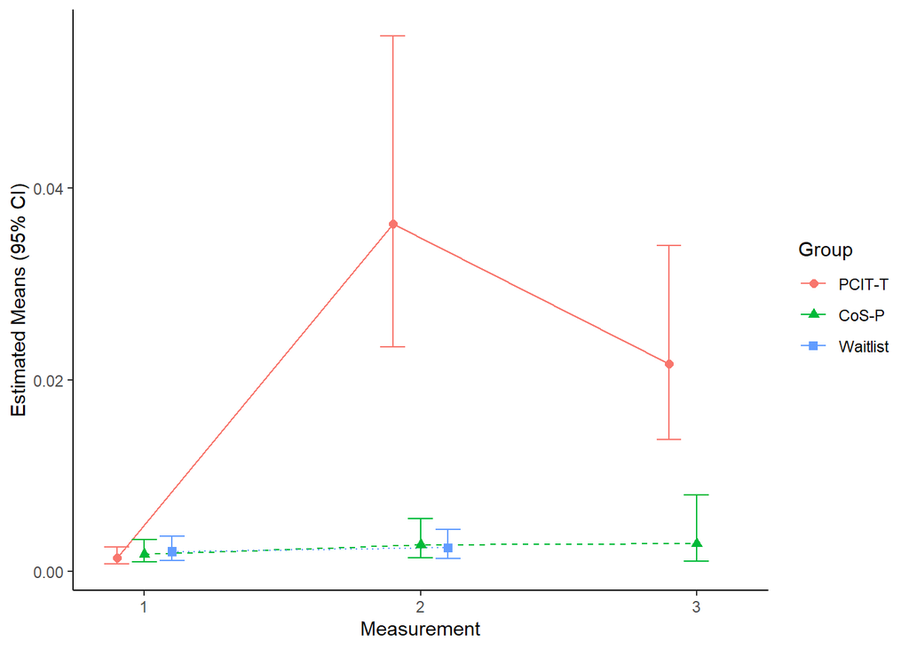

#### Hypothesis 1

We hypothesize that from baseline (‘T1’) to post-treatment/waitlist (‘T2’) there will be a gradient effect, whereby parent-child dyads who receive PCIT-T will show the greatest gains and parent-child dyads who receive no treatment will show the least gains. For the outcome, then, the null hypothesis is:

$H_0: \text {mean change}(\text{PCIT-T}) = \text {mean change}(\text{CoS-P}) = \text {mean change}(\text{Waitlist})$ $H_A: \text {mean change}(\text{PCIT-T}) > \text {mean change}(\text{CoS-P}) > \text {mean change}(\text{Waitlist})$

This is a joint hypothesis test.

First, confirming that the ordering of the means is as hypothesized:

```
## group = 1:
##  contrast odds.ratio      SE  df asymp.LCL asymp.UCL
##  1 / 2        0.0374 0.00863 Inf    0.0218    0.0642
##  1 / 3        0.0636 0.01511 Inf    0.0364    0.1110
##  2 / 3        1.7003 0.15541 Inf    1.3724    2.1065
##
## group = 2:
##  contrast odds.ratio      SE  df asymp.LCL asymp.UCL
##  1 / 2        0.6504 0.17015 Inf    0.3523    1.2008
##  1 / 3        0.6230 0.30144 Inf    0.2004    1.9363
##  2 / 3        0.9579 0.47207 Inf    0.3018    3.0404
##
## group = 3:
##  contrast odds.ratio      SE  df asymp.LCL asymp.UCL
##  1 / 2        0.8324 0.17669 Inf    0.5062    1.3690
##  1 / 3        nonEst      NA  NA        NA        NA
##  2 / 3        nonEst      NA  NA        NA        NA
##
## Results are averaged over the levels of: asdcase
## Confidence level used: 0.95
## Conf-level adjustment: tukey method for comparing a family of 3 estimates
## Intervals are back-transformed from the log odds ratio scale
```

$\frac{1}{0.0374} = 26.7380$

and the CI limits:

$\frac{1}{0.0642} = 15.5763$

$\frac{1}{0.0218} = 45.8716$

Here, the odds of an LP verbalisation are 26 times higher at time 2 than time 1 for PCIT-T. You should temper this HUGE number with the fact that the proportions of LP actions is very small, regardless of the time and group, however (.14% at time 1, and 3.6% at time 2 for PCIT-T.

Now, to get the p-value associated with the joint hypothesis.

```r
## Specify contrast matrices
# Hyp1 is 1 df test
# could use alternative="less" ir alternative="greater" in glht
hyp1   <- matrix(c(0, 0, 0,0, 0,0, -1,0,0 ),1)
# Hyp2 is 1 df test,
hyp2   <- matrix(c(0, 0, 0,0, 0,1, 0,1,0 ),1)


# hypF is combined 2df test. Yes!
h<-rbind(hyp1,hyp2)
hypF <- as.matrix(h)
GlobalF <- glht(result3, linfct = hypF, test = Ftest())
GlobalF$linfct
```

```
##   (Intercept) asdcase1 group2 group3 time2 time3 group2:time2 group3:time2
## 1           0        0      0      0     0     0           -1            0
## 2           0        0      0      0     0     1            0            1
##   group2:time3
## 1            0
## 2            0
```

```r
summary(GlobalF, test = Ftest())
```

```
##
##   General Linear Hypotheses
##
## Linear Hypotheses:
##        Estimate
## 1 == 0   2.8562
## 2 == 0  -0.3474
##
## Global Test:
##       F DF1 DF2    Pr(>F)
## 1 34.31   2 162 3.765e-13
```

```r
#also see this webpage for more on contrasts https://rcompanion.org/rcompanion/h_01.html
```

p<0.05 so this hypothesis is supported.

#### Hypothesis 2

There will be a gradient of size of change from T2 to T3 such that the change in the PCIT-T group > the change in the CoS-P group. This isn’t really a gradient; it’s just 1 hypothesis.

First, the change in PCITT and COSP from time 2 to time 3:

```
## group = 1:
##  time    prob       SE  df asymp.LCL asymp.UCL
##  1    0.00141 0.000428 Inf  0.000776   0.00255
##  2    0.03632 0.008066 Inf  0.023432   0.05590
##  3    0.02169 0.005011 Inf  0.013763   0.03402
##
## group = 2:
##  time    prob       SE  df asymp.LCL asymp.UCL
##  1    0.00182 0.000572 Inf  0.000982   0.00337
##  2    0.00279 0.000978 Inf  0.001406   0.00554
##  3    0.00292 0.001508 Inf  0.001058   0.00802
##
## group = 3:
##  time    prob       SE  df asymp.LCL asymp.UCL
##  1    0.00206 0.000606 Inf  0.001160   0.00367
##  2    0.00248 0.000736 Inf  0.001384   0.00443
##  3     nonEst       NA  NA        NA        NA
##
## Results are averaged over the levels of: asdcase
## Confidence level used: 0.95
## Intervals are back-transformed from the logit scale
```

```
## group = 1:
##  contrast odds.ratio      SE  df asymp.LCL asymp.UCL
##  1 / 2        0.0374 0.00863 Inf    0.0218    0.0642
##  1 / 3        0.0636 0.01511 Inf    0.0364    0.1110
##  2 / 3        1.7003 0.15541 Inf    1.3724    2.1065
##
## group = 2:
##  contrast odds.ratio      SE  df asymp.LCL asymp.UCL
##  1 / 2        0.6504 0.17015 Inf    0.3523    1.2008
##  1 / 3        0.6230 0.30144 Inf    0.2004    1.9363
##  2 / 3        0.9579 0.47207 Inf    0.3018    3.0404
##
## group = 3:
##  contrast odds.ratio      SE  df asymp.LCL asymp.UCL
##  1 / 2        0.8324 0.17669 Inf    0.5062    1.3690
##  1 / 3        nonEst      NA  NA        NA        NA
##  2 / 3        nonEst      NA  NA        NA        NA
##
## Results are averaged over the levels of: asdcase
## Confidence level used: 0.95
## Conf-level adjustment: tukey method for comparing a family of 3 estimates
## Intervals are back-transformed from the log odds ratio scale
```

```r
## Specify contrast matrices
# Hyp1 is 1 df test
# could use alternative="less" ir alternative="greater" in glht
hyp2   <- matrix(c(0, 0, 0,0, 0,0, -1,0,1 ),1)
hyp2F <- glht(result3, linfct = hyp2)
summary(hyp2F)
```

```
##
##   Simultaneous Tests for General Linear Hypotheses
##
## Fit: glmer(formula = cbind(lp, verbal - lp) ~ asdcase + group + time +
##     group * time + (1 | id), data = p, family = binomial)
##
## Linear Hypotheses:
##        Estimate Std. Error z value Pr(>|z|)
## 1 == 0   0.5738     0.5013   1.145    0.252
## (Adjusted p values reported -- single-step method)
```

```r
#also see this webpage for more on contrasts https://rcompanion.org/rcompanion/h_01.html
```

p>0.05, so this null hypotheiss connote rejected. However, it is important to note that the prportions at time 3 for PCITT (2.2%) and COSP (0.29%) are very different.

#### Residuals

Before interpretation, we should examine model assumptions.

For this model (A generalized linear mixed model with binomial distribution and logit link, with random effect for individual), we have to use a different residual than for a linear mixed model. These are simulated residuals, using the DHARMa package in R (citation below).

Under H0 (perfect model, no violations of assumptions), we would expect a stra1ght line in the QQplot. The residuals against the fitted values should show no obvious pattern or outliers.

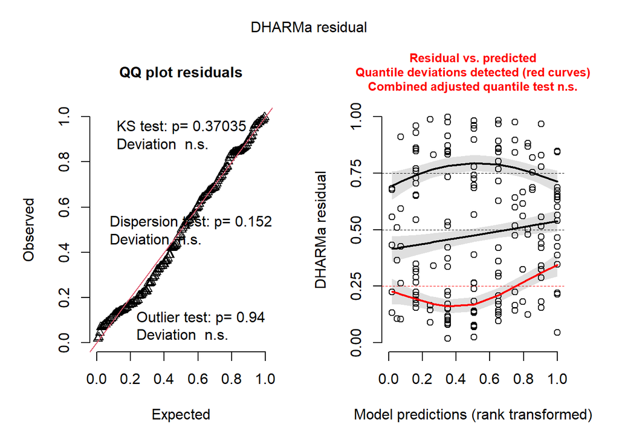

```r
library(DHARMa)

simulationOutput <- simulateResiduals(fittedModel = result3, plot = F)

plot(simulationOutput)
```

```r
citation("DHARMa")
```

```
##
##
##   Florian Hartig (2022). DHARMa: Residual Diagnostics for Hierarchical
##   (Multi-Level / Mixed) Regression Models. R package version 0.4.5.
##   https://CRAN.R-project.org/package=DHARMa
##
## A BibTeX entry for LaTeX users is
##
##   @Manual{,
##     title = {DHARMa: Residual Diagnostics for Hierarchical (Multi-Level / Mixed)
## Regression Models},
##     author = {Florian Hartig},
##     year = {2022},
##     note = {R package version 0.4.5},
##     url = {https://CRAN.R-project.org/package=DHARMa},
##   }
```

```r
rm(list = ls())
```

### DPICS NTA Controlling for ASD

#### Descriptives

| asdcase | group | time | n | mean | sd | median | min | max |
| --- | --- | --- | --- | --- | --- | --- | --- | --- |
| 0 | 1 | 1 | 24 | 4.1536402 | 3.2851693 | 3.5923020 | 0.3745318 | 12.672811 |
| 0 | 1 | 2 | 18 | 0.9846973 | 1.0901764 | 0.5698052 | 0.0000000 | 3.140097 |
| 0 | 1 | 3 | 13 | 0.9321502 | 1.2065783 | 0.4255319 | 0.0000000 | 4.385965 |
| 0 | 2 | 1 | 26 | 4.0367004 | 3.2879053 | 3.4002490 | 0.0000000 | 12.716763 |
| 0 | 2 | 2 | 10 | 2.9815837 | 2.9948797 | 1.9999126 | 0.3552398 | 9.325397 |
| 0 | 2 | 3 | 5 | 3.1532309 | 3.4081637 | 1.4760148 | 0.7352941 | 8.809524 |
| 0 | 3 | 1 | 25 | 4.1440762 | 3.3311484 | 3.1128405 | 0.8333333 | 14.077670 |
| 0 | 3 | 2 | 22 | 1.8389630 | 1.7043396 | 1.6866826 | 0.0000000 | 8.113590 |
| 0 | 3 | 3 | 1 | 0.9074410 | NA | 0.9074410 | 0.9074410 | 0.907441 |
| 1 | 1 | 1 | 6 | 4.1394936 | 2.8012139 | 3.6849222 | 0.6060606 | 8.908046 |
| 1 | 1 | 2 | 4 | 1.8304019 | 2.4506441 | 0.9958292 | 0.0000000 | 5.329949 |
| 1 | 1 | 3 | 5 | 0.9267725 | 0.8019167 | 0.9036145 | 0.0000000 | 2.056962 |
| 1 | 2 | 1 | 3 | 5.4763973 | 3.1416654 | 6.6202091 | 1.9230769 | 7.885906 |
| 1 | 2 | 2 | 2 | 1.9230769 | 2.7196415 | 1.9230769 | 0.0000000 | 3.846154 |
| 1 | 2 | 3 | 0 | NaN | NA | NA | Inf | -Inf |
| 1 | 3 | 1 | 5 | 7.4585265 | 7.0856157 | 6.6450567 | 1.2048193 | 18.820225 |
| 1 | 3 | 2 | 4 | 4.8712184 | 3.0877663 | 4.0477996 | 2.1035599 | 9.285714 |
| 1 | 3 | 3 | 0 | NaN | NA | NA | Inf | -Inf |

Note that with the number of ASD cases, it is unlikely that a model with the group*time* ASD interaction will run at all.

#### Model & Results

```
## fixed-effect model matrix is rank deficient so dropping 1 column / coefficient
```

```r
result4<-glmer(cbind(nta, verbal-nta) ~ asdcase*group*time + (1 | id), data=p, family=binomial)
```

```
## fixed-effect model matrix is rank deficient so dropping 3 columns / coefficients
```

This is the ANOVA table for the model. p-values are likelihood ratio tests for adding the new term to the model just before. A p-value <0.05 indicates that adding that term results in better model fit.

|  | Effect | npar | AIC | BIC | logLik | deviance | Chisq | Df | Pr(>Chisq) |
| --- | --- | --- | --- | --- | --- | --- | --- | --- | --- |
| result0 | Intercept | 2 | 1600.692 | 1606.987 | -798.3459 | 1596.692 | NA | NA | NA |
| result0_5 | ASD | 3 | 1601.643 | 1611.085 | -797.8213 | 1595.643 | 1.049295 | 1 | 0.3056695 |
| result1 | ASD + Group | 5 | 1601.736 | 1617.474 | -795.8682 | 1591.736 | 3.906097 | 2 | 0.1418410 |
| result2 | ASD + Group + Time | 7 | 1340.706 | 1362.739 | -663.3532 | 1326.706 | 265.030003 | 2 | 0.0000000 |
| result3 | ASD + Group*Time | 10 | 1273.524 | 1304.999 | -626.7621 | 1253.524 | 73.182182 | 3 | 0.0000000 |

```r
summary(result3)
```

```
## Generalized linear mixed model fit by maximum likelihood (Laplace
##   Approximation) [glmerMod]
##  Family: binomial  ( logit )
## Formula: cbind(nta, verbal - nta) ~ asdcase + group + time + group * time +
##     (1 | id)
##    Data: p
##
##      AIC      BIC   logLik deviance df.resid
##   1273.5   1305.0   -626.8   1253.5      162
##
## Scaled residuals:
##     Min      1Q  Median      3Q     Max
## -3.5982 -0.9456 -0.0302  0.4283  4.1880
##
## Random effects:
##  Groups Name        Variance Std.Dev.
##  id     (Intercept) 0.6309   0.7943
## Number of obs: 172, groups:  id, 89
##
## Fixed effects:
##              Estimate Std. Error z value Pr(>|z|)
## (Intercept)  -3.44292    0.16416 -20.973  < 2e-16 ***
## asdcase1      0.34907    0.24527   1.423    0.155
## group2       -0.04538    0.22443  -0.202    0.840
## group3        0.12670    0.22016   0.575    0.565
## time2        -1.37468    0.11542 -11.911  < 2e-16 ***
## time3        -1.49797    0.14452 -10.365  < 2e-16 ***
## group2:time2  1.01253    0.15977   6.337 2.34e-10 ***
## group3:time2  0.60909    0.14197   4.290 1.78e-05 ***
## group2:time3  1.52147    0.21868   6.958 3.46e-12 ***
## ---
## Signif. codes:  0 '***' 0.001 '**' 0.01 '*' 0.05 '.' 0.1 ' ' 1
##
## Correlation of Fixed Effects:
##             (Intr) asdcs1 group2 group3 time2  time3  grp2:2 grp3:2
## asdcase1    -0.298
## group2      -0.692  0.101
## group3      -0.686  0.030  0.497
## time2       -0.119 -0.002  0.088  0.089
## time3       -0.101 -0.020  0.075  0.079  0.170
## group2:tim2  0.087 -0.002 -0.128 -0.065 -0.722 -0.123
## group3:tim2  0.095  0.007 -0.071 -0.137 -0.813 -0.139  0.587
## group2:tim3  0.063  0.020 -0.103 -0.051 -0.113 -0.661  0.235  0.092
## fit warnings:
## fixed-effect model matrix is rank deficient so dropping 1 column / coefficient
```

#### Estimated Means & Change

Estimated means for each Treatment and Time are presented. In addition, within-group change between time points is presented with 95% CIs.

```r
# type="response" means that the emms are transformed and presented on the orginal scale
# This website has a nice demonstration of emmeans with GLMM https://cran.r-project.org/web/packages/emmeans/vignettes/transformations.html

result.change  <- emmeans(result3, "time", by = "group", type = "response")
# Differences give ODDS RATIOS
result.change.d <-pairs(result.change)
summary(result.change)
```

```
## group = 1:
##  time    prob      SE  df asymp.LCL asymp.UCL
##  1    0.03667 0.00612 Inf   0.02639    0.0507
##  2    0.00954 0.00186 Inf   0.00650    0.0140
##  3    0.00844 0.00178 Inf   0.00557    0.0128
##
## group = 2:
##  time    prob      SE  df asymp.LCL asymp.UCL
##  1    0.03510 0.00633 Inf   0.02460    0.0499
##  2    0.02470 0.00496 Inf   0.01663    0.0365
##  3    0.03591 0.00825 Inf   0.02282    0.0561
##
## group = 3:
##  time    prob      SE  df asymp.LCL asymp.UCL
##  1    0.04142 0.00694 Inf   0.02977    0.0574
##  2    0.01970 0.00353 Inf   0.01385    0.0280
##  3     nonEst      NA  NA        NA        NA
##
## Results are averaged over the levels of: asdcase
## Confidence level used: 0.95
## Intervals are back-transformed from the logit scale
```

```r
confint(result.change.d)
```

```
## group = 1:
##  contrast odds.ratio    SE  df asymp.LCL asymp.UCL
##  1 / 2         3.954 0.456 Inf     3.017      5.18
##  1 / 3         4.473 0.646 Inf     3.188      6.28
##  2 / 3         1.131 0.191 Inf     0.761      1.68
##
## group = 2:
##  contrast odds.ratio    SE  df asymp.LCL asymp.UCL
##  1 / 2         1.436 0.159 Inf     1.109      1.86
##  1 / 3         0.977 0.160 Inf     0.665      1.44
##  2 / 3         0.680 0.115 Inf     0.458      1.01
##
## group = 3:
##  contrast odds.ratio    SE  df asymp.LCL asymp.UCL
##  1 / 2         2.150 0.178 Inf     1.772      2.61
##  1 / 3        nonEst    NA  NA        NA        NA
##  2 / 3        nonEst    NA  NA        NA        NA
##
## Results are averaged over the levels of: asdcase
## Confidence level used: 0.95
## Conf-level adjustment: tukey method for comparing a family of 3 estimates
## Intervals are back-transformed from the log odds ratio scale
```

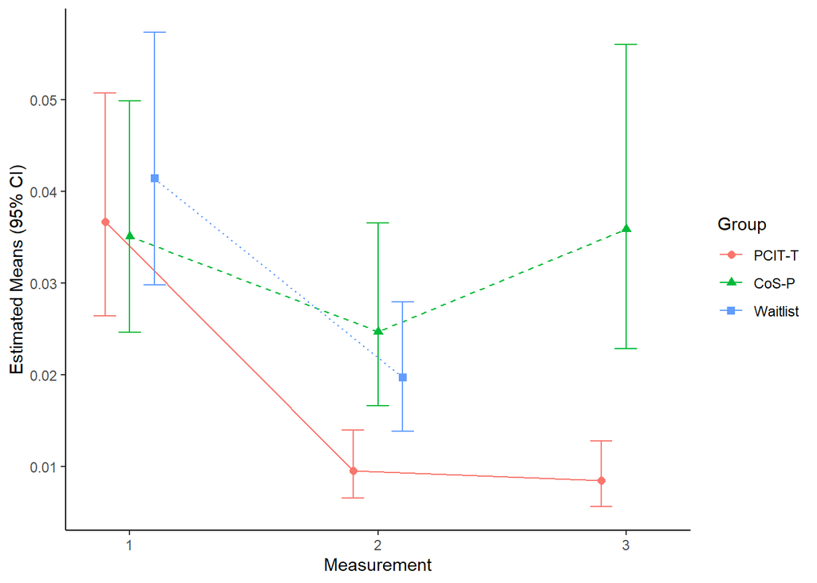

#### Hypothesis 1

We hypothesize that from baseline (‘T1’) to post-treatment/waitlist (‘T2’) there will be a gradient effect, whereby parent-child dyads who receive PCIT-T will show the greatest gains and parent-child dyads who receive no treatment will show the least gains. For the outcome, then, the null hypothesis is:

$H_0: \text {mean change}(\text{PCIT-T}) = \text {mean change}(\text{CoS-P}) = \text {mean change}(\text{Waitlist})$ $H_A: \text {mean change}(\text{PCIT-T}) > \text {mean change}(\text{CoS-P}) > \text {mean change}(\text{Waitlist})$

This is a joint hypothesis test.

First, confirming that the ordering of the means is as hypothesized:

```
## group = 1:
##  contrast odds.ratio    SE  df asymp.LCL asymp.UCL
##  1 / 2         3.954 0.456 Inf     3.017      5.18
##  1 / 3         4.473 0.646 Inf     3.188      6.28
##  2 / 3         1.131 0.191 Inf     0.761      1.68
##
## group = 2:
##  contrast odds.ratio    SE  df asymp.LCL asymp.UCL
##  1 / 2         1.436 0.159 Inf     1.109      1.86
##  1 / 3         0.977 0.160 Inf     0.665      1.44
##  2 / 3         0.680 0.115 Inf     0.458      1.01
##
## group = 3:
##  contrast odds.ratio    SE  df asymp.LCL asymp.UCL
##  1 / 2         2.150 0.178 Inf     1.772      2.61
##  1 / 3        nonEst    NA  NA        NA        NA
##  2 / 3        nonEst    NA  NA        NA        NA
##
## Results are averaged over the levels of: asdcase
## Confidence level used: 0.95
## Conf-level adjustment: tukey method for comparing a family of 3 estimates
## Intervals are back-transformed from the log odds ratio scale
```

so, change from t1 to t2 is represented as an OR. They way these results are presented, a value >1 means that there is an *decrease* from T1 to T2. So, for PCIT-T, the OR=3.954, indicating that the odds of an NTA action in the total verbalisations is much larger by a factor of 3.954 at T1 relative to T2. Alternatively, we can take the reciprocal

$\frac{1}{3.9544} = 0.25288$

and the CI limits:

$\frac{1}{5.18} = 0.1930502$

$\frac{1}{3.017} = 0.3314551$

Here, the odds of an NTA verbalisation are 0.25 times that at time 2 than time 1 for PCIT-T (odds reduced by 75%).

Now, to get the p-value associated with the joint hypothesis.

```r
## Specify contrast matrices
# Hyp1 is 1 df test
# could use alternative="less" ir alternative="greater" in glht
hyp1   <- matrix(c(0, 0, 0,0, 0,0, -1,0,0 ),1)
# Hyp2 is 1 df test,
hyp2   <- matrix(c(0, 0, 0,0, 0,1, 0,1,0 ),1)


# hypF is combined 2df test. Yes!
h<-rbind(hyp1,hyp2)
hypF <- as.matrix(h)
GlobalF <- glht(result3, linfct = hypF, test = Ftest())
GlobalF$linfct
```

```
##   (Intercept) asdcase1 group2 group3 time2 time3 group2:time2 group3:time2
## 1           0        0      0      0     0     0           -1            0
## 2           0        0      0      0     0     1            0            1
##   group2:time3
## 1            0
## 2            0
```

```r
summary(GlobalF, test = Ftest())
```

```
##
##   General Linear Hypotheses
##
## Linear Hypotheses:
##        Estimate
## 1 == 0  -1.0125
## 2 == 0  -0.8889
##
## Global Test:
##       F DF1 DF2    Pr(>F)
## 1 47.49   2 162 5.877e-17
```

```r
#also see this webpage for more on contrasts https://rcompanion.org/rcompanion/h_01.html
```

#### Hypothesis 2

There will be a gradient of size of change from T2 to T3 such that the change in the PCIT-T group > the change in the CoS-P group. This isn’t really a gradient; it’s just 1 hypothesis.

First, the change in PCITT and COSP from time 2 to time 3:

```
## group = 1:
##  time    prob      SE  df asymp.LCL asymp.UCL
##  1    0.03667 0.00612 Inf   0.02639    0.0507
##  2    0.00954 0.00186 Inf   0.00650    0.0140
##  3    0.00844 0.00178 Inf   0.00557    0.0128
##
## group = 2:
##  time    prob      SE  df asymp.LCL asymp.UCL
##  1    0.03510 0.00633 Inf   0.02460    0.0499
##  2    0.02470 0.00496 Inf   0.01663    0.0365
##  3    0.03591 0.00825 Inf   0.02282    0.0561
##
## group = 3:
##  time    prob      SE  df asymp.LCL asymp.UCL
##  1    0.04142 0.00694 Inf   0.02977    0.0574
##  2    0.01970 0.00353 Inf   0.01385    0.0280
##  3     nonEst      NA  NA        NA        NA
##
## Results are averaged over the levels of: asdcase
## Confidence level used: 0.95
## Intervals are back-transformed from the logit scale
```

```
## group = 1:
##  contrast odds.ratio    SE  df asymp.LCL asymp.UCL
##  1 / 2         3.954 0.456 Inf     3.017      5.18
##  1 / 3         4.473 0.646 Inf     3.188      6.28
##  2 / 3         1.131 0.191 Inf     0.761      1.68
##
## group = 2:
##  contrast odds.ratio    SE  df asymp.LCL asymp.UCL
##  1 / 2         1.436 0.159 Inf     1.109      1.86
##  1 / 3         0.977 0.160 Inf     0.665      1.44
##  2 / 3         0.680 0.115 Inf     0.458      1.01
##
## group = 3:
##  contrast odds.ratio    SE  df asymp.LCL asymp.UCL
##  1 / 2         2.150 0.178 Inf     1.772      2.61
##  1 / 3        nonEst    NA  NA        NA        NA
##  2 / 3        nonEst    NA  NA        NA        NA
##
## Results are averaged over the levels of: asdcase
## Confidence level used: 0.95
## Conf-level adjustment: tukey method for comparing a family of 3 estimates
## Intervals are back-transformed from the log odds ratio scale
```

```r
## Specify contrast matrices
# Hyp1 is 1 df test
# could use alternative="less" ir alternative="greater" in glht
hyp2   <- matrix(c(0, 0, 0,0, 0,0, -1,0,1 ),1)
hyp2F <- glht(result3, linfct = hyp2)
summary(hyp2F)
```

```
##
##   Simultaneous Tests for General Linear Hypotheses
##
## Fit: glmer(formula = cbind(nta, verbal - nta) ~ asdcase + group +
##     time + group * time + (1 | id), data = p, family = binomial)
##
## Linear Hypotheses:
##        Estimate Std. Error z value Pr(>|z|)
## 1 == 0   0.5089     0.2386   2.133   0.0329 *
## ---
## Signif. codes:  0 '***' 0.001 '**' 0.01 '*' 0.05 '.' 0.1 ' ' 1
## (Adjusted p values reported -- single-step method)
```

```r
#also see this webpage for more on contrasts https://rcompanion.org/rcompanion/h_01.html
```

p<0.05, so this null is rejected. There is a difference in the estimated mean proportion of NTA verbalisations between PCITT and COSP at T3.

#### Residuals

Before interpretation, we should examine model assumptions.

For this model (A generalized linear mixed model with binomial distribution and logit link, with random effect for individual), we have to use a different residual than for a linear mixed model. These are simulated residuals, using the DHARMa package in R (citation below).

Under H0 (perfect model, no violations of assumptions), we would expect a stra1ght line in the QQplot. The residuals against the fitted values should show no obvious pattern or outliers.

There are no violations of assumptions.

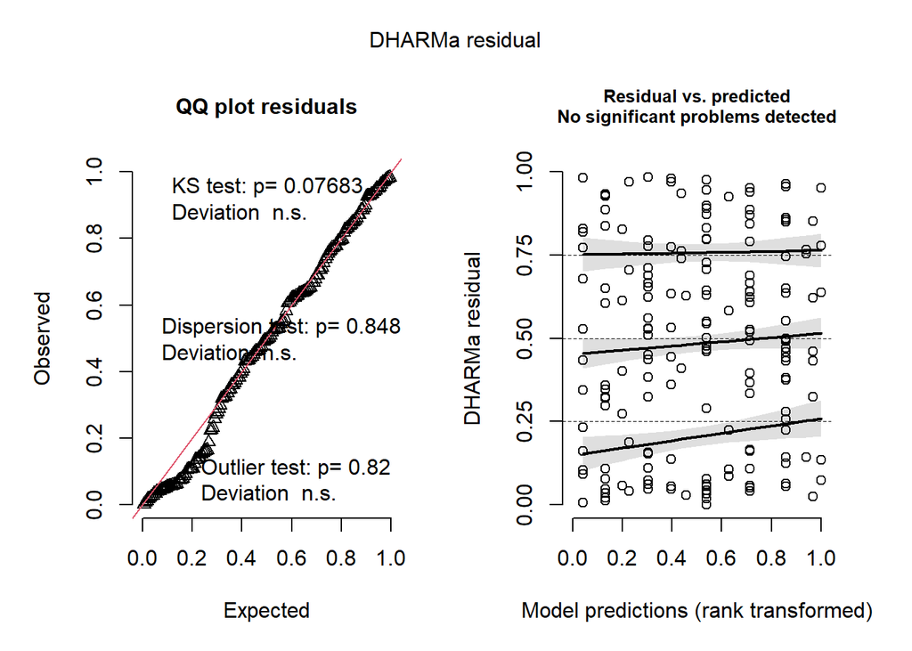

```r
library(DHARMa)

simulationOutput <- simulateResiduals(fittedModel = result3, plot = F)

plot(simulationOutput)
```

```r
citation("DHARMa")
```

```
##
##
##   Florian Hartig (2022). DHARMa: Residual Diagnostics for Hierarchical
##   (Multi-Level / Mixed) Regression Models. R package version 0.4.5.
##   https://CRAN.R-project.org/package=DHARMa
##
## A BibTeX entry for LaTeX users is
##
##   @Manual{,
##     title = {DHARMa: Residual Diagnostics for Hierarchical (Multi-Level / Mixed)
## Regression Models},
##     author = {Florian Hartig},
##     year = {2022},
##     note = {R package version 0.4.5},
##     url = {https://CRAN.R-project.org/package=DHARMa},
##   }
```

```r
rm(list = ls())
```

### DPICS Child Compliance, Controlling for ASD

#### Descriptives

| asdcase | group | time | n | mean | sd | median | min | max |
| --- | --- | --- | --- | --- | --- | --- | --- | --- |
| 0 | 1 | 1 | 23 | 47.54954 | 16.286511 | 43.75000 | 20.000000 | 82.35294 |
| 0 | 1 | 2 | 18 | 52.09804 | 12.623970 | 54.05844 | 33.333333 | 75.00000 |
| 0 | 1 | 3 | 13 | 59.42900 | 23.083091 | 66.66667 | 14.285714 | 85.00000 |
| 0 | 2 | 1 | 26 | 47.26659 | 17.804178 | 41.88596 | 16.000000 | 78.57143 |
| 0 | 2 | 2 | 10 | 54.78738 | 26.169305 | 66.76413 | 9.756098 | 79.16667 |
| 0 | 2 | 3 | 5 | 65.40371 | 15.589835 | 65.51724 | 47.826087 | 88.88889 |
| 0 | 3 | 1 | 23 | 49.40582 | 13.863914 | 48.27586 | 25.000000 | 76.00000 |
| 0 | 3 | 2 | 19 | 50.35400 | 14.946307 | 47.05882 | 28.947368 | 78.57143 |
| 0 | 3 | 3 | 0 | NaN | NA | NA | Inf | -Inf |
| 1 | 1 | 1 | 6 | 45.11607 | 8.190289 | 45.00000 | 34.000000 | 53.57143 |
| 1 | 1 | 2 | 3 | 58.44915 | 8.703468 | 54.54545 | 52.380952 | 68.42105 |
| 1 | 1 | 3 | 5 | 40.05195 | 26.741991 | 28.57143 | 10.000000 | 78.57143 |
| 1 | 2 | 1 | 3 | 41.03102 | 21.193971 | 47.36842 | 17.391304 | 58.33333 |
| 1 | 2 | 2 | 2 | 37.83069 | 19.828920 | 37.83069 | 23.809524 | 51.85185 |
| 1 | 2 | 3 | 0 | NaN | NA | NA | Inf | -Inf |
| 1 | 3 | 1 | 5 | 47.77903 | 15.273695 | 55.55556 | 26.315790 | 62.85714 |
| 1 | 3 | 2 | 3 | 46.32683 | 32.575570 | 45.28302 | 14.285714 | 79.41176 |
| 1 | 3 | 3 | 0 | NaN | NA | NA | Inf | -Inf |

Note that with the number of ASD cases, it is unlikely that a model with the group*time* ASD interaction will run at all.

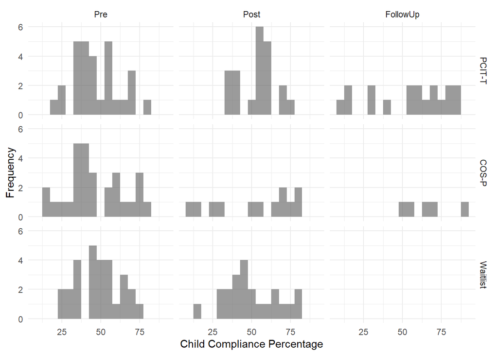

#### Model & Results

```
## fixed-effect model matrix is rank deficient so dropping 1 column / coefficient
```

```r
result4<-glmer(cbind(co, effcommands-co) ~ asdcase*group*time + (1 | id), data=p, family=binomial)
```

```
## fixed-effect model matrix is rank deficient so dropping 3 columns / coefficients
```

```r
summary(result4)
```

```
## Generalized linear mixed model fit by maximum likelihood (Laplace
##   Approximation) [glmerMod]
##  Family: binomial  ( logit )
## Formula: cbind(co, effcommands - co) ~ asdcase * group * time + (1 | id)
##    Data: p
##
##      AIC      BIC   logLik deviance df.resid
##    989.7   1039.3   -478.8    957.7      148
##
## Scaled residuals:
##     Min      1Q  Median      3Q     Max
## -3.5982 -0.6201 -0.0582  0.7033  2.7043
##
## Random effects:
##  Groups Name        Variance Std.Dev.
##  id     (Intercept) 0.2598   0.5097
## Number of obs: 164, groups:  id, 88
##
## Fixed effects:
##                       Estimate Std. Error z value Pr(>|z|)
## (Intercept)           -0.06356    0.13446  -0.473   0.6364
## asdcase1              -0.16112    0.30523  -0.528   0.5976
## group2                -0.03543    0.18468  -0.192   0.8478
## group3                 0.03990    0.18588   0.215   0.8301
## time2                  0.23879    0.14957   1.596   0.1104
## time3                  0.38976    0.16913   2.305   0.0212 *
## asdcase1:group2       -0.12115    0.49989  -0.242   0.8085
## asdcase1:group3        0.15024    0.43901   0.342   0.7322
## asdcase1:time2         0.53236    0.36962   1.440   0.1498
## asdcase1:time3        -0.60557    0.33139  -1.827   0.0676 .
## group2:time2           0.06299    0.21710   0.290   0.7717
## group3:time2          -0.23270    0.18833  -1.236   0.2166
## group2:time3           0.02062    0.28011   0.074   0.9413
## asdcase1:group2:time2 -1.24147    0.55697  -2.229   0.0258 *
## asdcase1:group3:time2 -0.58611    0.47741  -1.228   0.2196
## ---
## Signif. codes:  0 '***' 0.001 '**' 0.01 '*' 0.05 '.' 0.1 ' ' 1
```

```
##
## Correlation matrix not shown by default, as p = 15 > 12.
## Use print(x, correlation=TRUE)  or
##     vcov(x)        if you need it
```

```
## fit warnings:
## fixed-effect model matrix is rank deficient so dropping 3 columns / coefficients
```

This is the ANOVA table for the model. p-values are likelihood ratio tests for adding the new term to the model just before. A p-value <0.05 indicates that adding that term results in better model fit.

|  | Effect | npar | AIC | BIC | logLik | deviance | Chisq | Df | Pr(>Chisq) |
| --- | --- | --- | --- | --- | --- | --- | --- | --- | --- |
| result0 | Intercept | 2 | 985.2588 | 991.4585 | -490.6294 | 981.2588 | NA | NA | NA |
| result0_5 | ASD | 3 | 985.8982 | 995.1978 | -489.9491 | 979.8982 | 1.3606481 | 1 | 0.2434252 |
| result1 | ASD + Group | 5 | 989.4274 | 1004.9267 | -489.7137 | 979.4274 | 0.4707563 | 2 | 0.7902720 |
| result2 | ASD + Group + Time | 7 | 988.2671 | 1009.9662 | -487.1336 | 974.2671 | 5.1602962 | 2 | 0.0757628 |
| result3 | ASD + Group*Time | 10 | 990.1737 | 1021.1724 | -485.0869 | 970.1737 | 4.0933740 | 3 | 0.2515563 |
| result4 | ASD*Group*Time | 16 | 989.6817 | 1039.2796 | -478.8409 | 957.6817 | 12.4920068 | 6 | 0.0518509 |

###### Assuming result4

```r
summary(result4)
```

```
## Generalized linear mixed model fit by maximum likelihood (Laplace
##   Approximation) [glmerMod]
##  Family: binomial  ( logit )
## Formula: cbind(co, effcommands - co) ~ asdcase * group * time + (1 | id)
##    Data: p
##
##      AIC      BIC   logLik deviance df.resid
##    989.7   1039.3   -478.8    957.7      148
##
## Scaled residuals:
##     Min      1Q  Median      3Q     Max
## -3.5982 -0.6201 -0.0582  0.7033  2.7043
##
## Random effects:
##  Groups Name        Variance Std.Dev.
##  id     (Intercept) 0.2598   0.5097
## Number of obs: 164, groups:  id, 88
##
## Fixed effects:
##                       Estimate Std. Error z value Pr(>|z|)
## (Intercept)           -0.06356    0.13446  -0.473   0.6364
## asdcase1              -0.16112    0.30523  -0.528   0.5976
## group2                -0.03543    0.18468  -0.192   0.8478
## group3                 0.03990    0.18588   0.215   0.8301
## time2                  0.23879    0.14957   1.596   0.1104
## time3                  0.38976    0.16913   2.305   0.0212 *
## asdcase1:group2       -0.12115    0.49989  -0.242   0.8085
## asdcase1:group3        0.15024    0.43901   0.342   0.7322
## asdcase1:time2         0.53236    0.36962   1.440   0.1498
## asdcase1:time3        -0.60557    0.33139  -1.827   0.0676 .
## group2:time2           0.06299    0.21710   0.290   0.7717
## group3:time2          -0.23270    0.18833  -1.236   0.2166
## group2:time3           0.02062    0.28011   0.074   0.9413
## asdcase1:group2:time2 -1.24147    0.55697  -2.229   0.0258 *
## asdcase1:group3:time2 -0.58611    0.47741  -1.228   0.2196
## ---
## Signif. codes:  0 '***' 0.001 '**' 0.01 '*' 0.05 '.' 0.1 ' ' 1
```

```
##
## Correlation matrix not shown by default, as p = 15 > 12.
## Use print(x, correlation=TRUE)  or
##     vcov(x)        if you need it
```

```
## fit warnings:
## fixed-effect model matrix is rank deficient so dropping 3 columns / coefficients
```

#### Estimated Means & Change

Estimated means for each Treatment and Time are presented. In addition, within-group change between time points is presented with 95% CIs.

```r
# type="response" means that the emms are transformed and presented on the orginal scale
# This website has a nice demonstration of emmeans with GLMM https://cran.r-project.org/web/packages/emmeans/vignettes/transformations.html

result.change  <- emmeans(result4, "time", by = c("group","asdcase"), type = "response")
# Differences give ODDS RATIOS
result.change.d <-pairs(result.change)
summary(result.change)
```

```
## group = 1, asdcase = 0:
##  time   prob     SE  df asymp.LCL asymp.UCL
##  1     0.484 0.0336 Inf     0.419     0.550
##  2     0.544 0.0398 Inf     0.465     0.620
##  3     0.581 0.0431 Inf     0.495     0.662
##
## group = 2, asdcase = 0:
##  time   prob     SE  df asymp.LCL asymp.UCL
##  1     0.475 0.0316 Inf     0.414     0.537
##  2     0.551 0.0431 Inf     0.465     0.633
##  3     0.577 0.0575 Inf     0.463     0.684
##
## group = 3, asdcase = 0:
##  time   prob     SE  df asymp.LCL asymp.UCL
##  1     0.494 0.0321 Inf     0.432     0.557
##  2     0.496 0.0343 Inf     0.429     0.563
##  3    nonEst     NA  NA        NA        NA
##
## group = 1, asdcase = 1:
##  time   prob     SE  df asymp.LCL asymp.UCL
##  1     0.444 0.0676 Inf     0.318     0.577
##  2     0.633 0.0820 Inf     0.464     0.775
##  3     0.392 0.0708 Inf     0.264     0.535
##
## group = 2, asdcase = 1:
##  time   prob     SE  df asymp.LCL asymp.UCL
##  1     0.406 0.0904 Inf     0.247     0.588
##  2     0.312 0.0953 Inf     0.160     0.520
##  3    nonEst     NA  NA        NA        NA
##
## group = 3, asdcase = 1:
##  time   prob     SE  df asymp.LCL asymp.UCL
##  1     0.491 0.0720 Inf     0.355     0.629
##  2     0.479 0.0834 Inf     0.324     0.639
##  3    nonEst     NA  NA        NA        NA
##
## Confidence level used: 0.95
## Intervals are back-transformed from the logit scale
```

```r
confint(result.change)
```

```
## group = 1, asdcase = 0:
##  time   prob     SE  df asymp.LCL asymp.UCL
##  1     0.484 0.0336 Inf     0.419     0.550
##  2     0.544 0.0398 Inf     0.465     0.620
##  3     0.581 0.0431 Inf     0.495     0.662
##
## group = 2, asdcase = 0:
##  time   prob     SE  df asymp.LCL asymp.UCL
##  1     0.475 0.0316 Inf     0.414     0.537
##  2     0.551 0.0431 Inf     0.465     0.633
##  3     0.577 0.0575 Inf     0.463     0.684
##
## group = 3, asdcase = 0:
##  time   prob     SE  df asymp.LCL asymp.UCL
##  1     0.494 0.0321 Inf     0.432     0.557
##  2     0.496 0.0343 Inf     0.429     0.563
##  3    nonEst     NA  NA        NA        NA
##
## group = 1, asdcase = 1:
##  time   prob     SE  df asymp.LCL asymp.UCL
##  1     0.444 0.0676 Inf     0.318     0.577
##  2     0.633 0.0820 Inf     0.464     0.775
##  3     0.392 0.0708 Inf     0.264     0.535
##
## group = 2, asdcase = 1:
##  time   prob     SE  df asymp.LCL asymp.UCL
##  1     0.406 0.0904 Inf     0.247     0.588
##  2     0.312 0.0953 Inf     0.160     0.520
##  3    nonEst     NA  NA        NA        NA
##
## group = 3, asdcase = 1:
##  time   prob     SE  df asymp.LCL asymp.UCL
##  1     0.491 0.0720 Inf     0.355     0.629
##  2     0.479 0.0834 Inf     0.324     0.639
##  3    nonEst     NA  NA        NA        NA
##
## Confidence level used: 0.95
## Intervals are back-transformed from the logit scale
```

```r
confint(result.change.d)
```

```
## group = 1, asdcase = 0:
##  contrast odds.ratio    SE  df asymp.LCL asymp.UCL
##  1 / 2         0.788 0.118 Inf     0.555      1.12
##  1 / 3         0.677 0.115 Inf     0.456      1.01
##  2 / 3         0.860 0.151 Inf     0.569      1.30
##
## group = 2, asdcase = 0:
##  contrast odds.ratio    SE  df asymp.LCL asymp.UCL
##  1 / 2         0.739 0.116 Inf     0.511      1.07
##  1 / 3         0.663 0.148 Inf     0.393      1.12
##  2 / 3         0.897 0.211 Inf     0.518      1.56
##
## group = 3, asdcase = 0:
##  contrast odds.ratio    SE  df asymp.LCL asymp.UCL
##  1 / 2         0.994 0.114 Inf     0.760      1.30
##  1 / 3        nonEst    NA  NA        NA        NA
##  2 / 3        nonEst    NA  NA        NA        NA
##
## group = 1, asdcase = 1:
##  contrast odds.ratio    SE  df asymp.LCL asymp.UCL
##  1 / 2         0.462 0.156 Inf     0.209      1.02
##  1 / 3         1.241 0.354 Inf     0.636      2.42
##  2 / 3         2.683 0.956 Inf     1.164      6.19
##
## group = 2, asdcase = 1:
##  contrast odds.ratio    SE  df asymp.LCL asymp.UCL
##  1 / 2         1.503 0.578 Inf     0.610      3.70
##  1 / 3        nonEst    NA  NA        NA        NA
##  2 / 3        nonEst    NA  NA        NA        NA
##
## group = 3, asdcase = 1:
##  contrast odds.ratio    SE  df asymp.LCL asymp.UCL
##  1 / 2         1.049 0.293 Inf     0.544      2.02
##  1 / 3        nonEst    NA  NA        NA        NA
##  2 / 3        nonEst    NA  NA        NA        NA
##
## Confidence level used: 0.95
## Conf-level adjustment: tukey method for comparing a family of 3 estimates
## Intervals are back-transformed from the log odds ratio scale
```

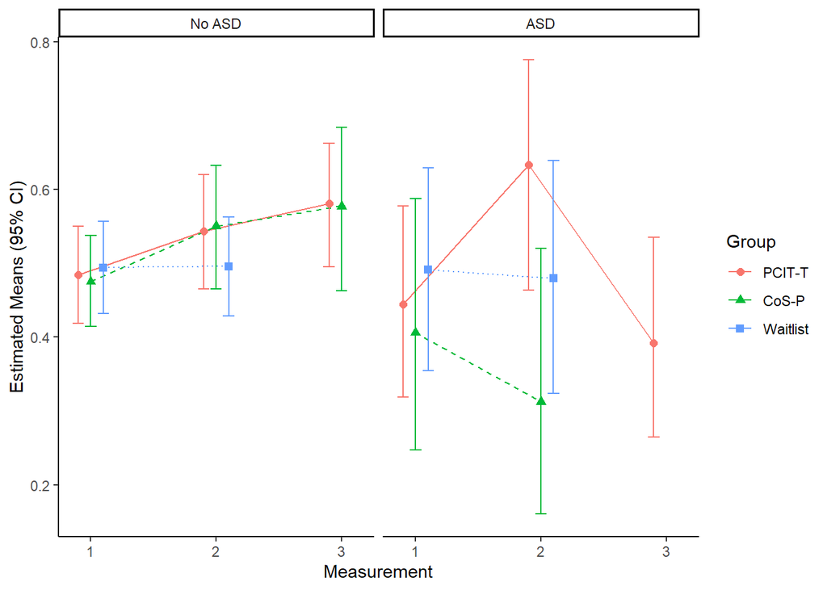

#### Hypothesis 1 Note I DID NOT SPECIFY ANYTHING FOr the 3WAY INTERACTION

We hypothesize that from baseline (‘T1’) to post-treatment/waitlist (‘T2’) there will be a gradient effect, whereby parent-child dyads who receive PCIT-T will show the greatest gains and parent-child dyads who receive no treatment will show the least gains. For the outcome, then, the null hypothesis is:

$H_0: \text {mean change}(\text{PCIT-T}) = \text {mean change}(\text{CoS-P}) = \text {mean change}(\text{Waitlist})$ $H_A: \text {mean change}(\text{PCIT-T}) > \text {mean change}(\text{CoS-P}) > \text {mean change}(\text{Waitlist})$

This is a joint hypothesis test.